# Analyses of GSE138988; GSE224858; GSE224752

# SG vs WC

## Linear Models

Now we must perform linear model fitting. Once more, we will have 4, one for each matrix we previously designed.

```r
fitted <- lmFit(y, mm)
head(coef(fitted))
```

```
##           SamplePB SampleRNP SampleSG SampleWC
## 7SK      0.3585752  4.554946 5.577907 6.164172
## A1BG-AS1 3.1174872  3.066850 3.178445 2.414839
## A2M      2.7090238  3.859096 3.382536 3.295809
## AAAS     4.1105954  5.487700 4.486423 5.649326
## AACS     5.1200856  6.119243 5.051033 5.792689
## AADAT    3.0913157  4.016408 3.646845 4.040018
```

```r
#next we measure contrasts between groups (log-fold change is obtained from these fitted linear models)
contr<- makeContrasts(SampleSG       - SampleWC       , levels = colnames(coef(fitted)))

#next we estimate the contrast for each gene
tmp <- contrasts.fit(fitted, contr)


#use empirical bayes smoothing of standard erros (shrinks extreme standard erros)
tmp <- eBayes(tmp)
top.table <- topTable(tmp, sort.by = "logFC", n = Inf)
DEGenes <- top.table
ndegs=20
```

## Volcano Plots

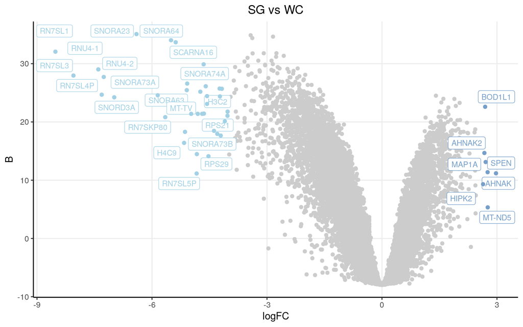

```r
upmarkers <- as.data.frame(DEGenes[DEGenes$logFC>2.5 & DEGenes$B>0,] )
downmarkers <- as.data.frame(DEGenes[DEGenes$logFC< -4 & DEGenes$B>0,] )

ggplot(data=DEGenes,
                 aes(x=logFC,
                     y=  B)) +
  geom_point(color="#CCCCCC")+
  theme_bw() +
  theme(axis.line = element_line(colour = "black"),
        panel.grid.minor = element_blank(),
        panel.border = element_blank(),
        panel.background = element_blank()) +
  ggtitle("SG vs WC")+
  theme(plot.title = element_text(hjust = 0.5)) +
  geom_label_repel(upmarkers[1:ndegs,] , mapping=aes(label=row.names(upmarkers)[1:ndegs]),size=3,point.padding=-0.5, color="#769fca",max.overlaps = 20)+
  geom_label_repel(downmarkers[1:ndegs,] , mapping=aes(label=row.names(downmarkers)[1:ndegs]),size=3,point.padding=-0.5, color="#a2d1e6",max.overlaps = 20)+
  geom_point(data=upmarkers, aes(x=logFC, y=  B), color="#769fca")+
  geom_point(data=downmarkers, aes(x=logFC, y=  B), color="#a2d1e6")
```

```r
#write.table(DEGenes, "~/Projects/StressGranules/SGPAPER/RealSGs/Tmathenypb.txt", row.names = T)
#rnp_t <- data.frame(Gene=row.names(DEGenes), rnp_t=DEGenes$t, rnp_logFC=DEGenes$logFC)
#pb_t <- data.frame(Gene=row.names(DEGenes), pb_t=DEGenes$t)
sg_t <- data.frame(Gene=row.names(DEGenes), sg_t=DEGenes$t)
```

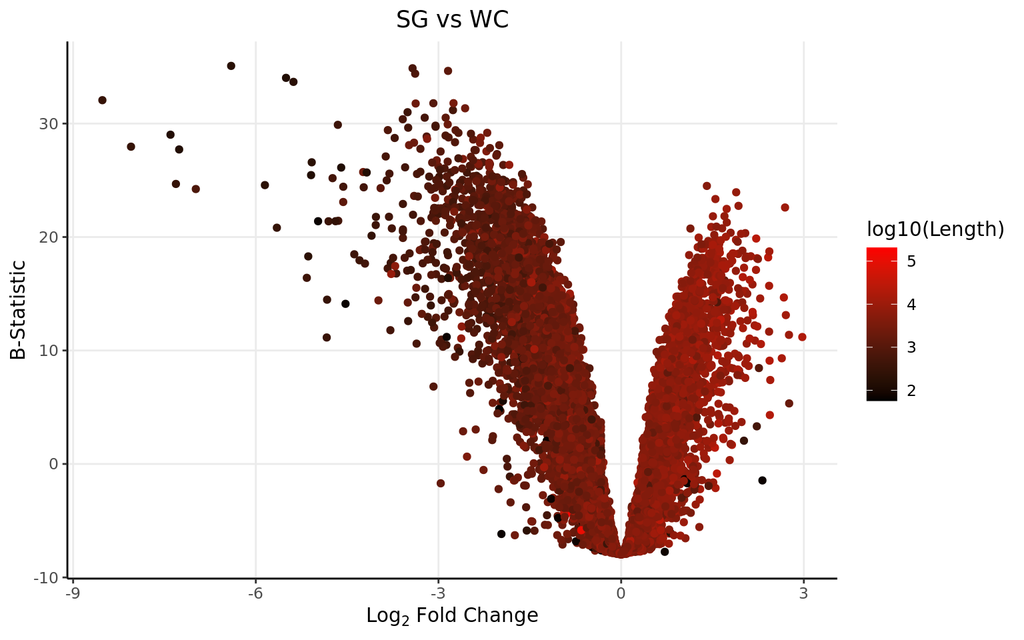

```r
DEGenes$Gene <- row.names(DEGenes)
colnames(genelength) <- c("Length","Gene")
DEGenes <- merge(DEGenes, genelength, by="Gene")

Pbody <- DEGenes[,c(1,2,4,8)]

ggplot(data=DEGenes,
                 aes(x=logFC,
                     y=  B)) +
  geom_point(aes(color=log10(Length)))+
  theme_bw() +
  theme(axis.line = element_line(colour = "black"),
        panel.grid.minor = element_blank(),
        panel.border = element_blank(),
        panel.background = element_blank()) +
  ggtitle("SG vs WC")+ xlab(expression(Log[2] ~ Fold ~ Change)) + ylab("B-Statistic") +
  theme(plot.title = element_text(hjust = 0.5))  +
  scale_colour_gradient(low = "black", high = "red")+ theme(text=element_text(family = "Quicksand"))
```

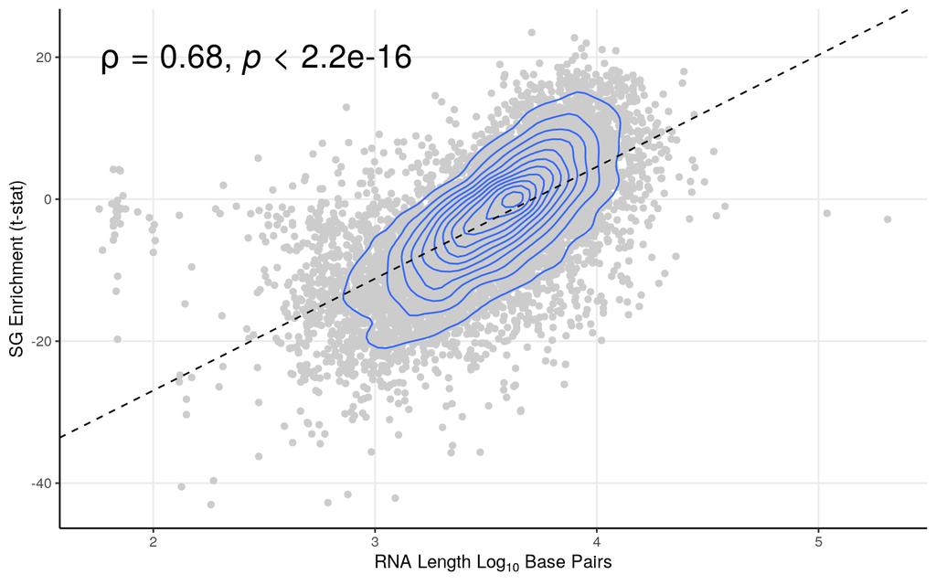

```r
smooth.SG <- lm(t~log10(Length), DEGenes)

ggplot(DEGenes, aes(y=t, x=log10(Length))) + geom_point(color="#CCCCCC", alpha=1) +   theme_bw()+ geom_density_2d()+
 ylab("SG Enrichment (t-stat)") + xlab(expression(RNA ~ Length ~ Log[10] ~ Base ~ Pairs)) +
  theme(axis.line = element_line(colour = "black"),
        panel.grid.minor = element_blank(),
        panel.border = element_blank(),
        panel.background = element_blank()) +
  theme(plot.title = element_text(hjust = 0.5))  +
  geom_abline(slope=smooth.SG$coefficients[2], intercept = smooth.SG$coefficients[1], linetype = "dashed")+ stat_cor(method = "spearman", cor.coef.name = "rho",size=7)
```

# RNP vs WC

## Linear Models

Now we must perform linear model fitting. Once more, we will have 4, one for each matrix we previously designed.

```r
fitted <- lmFit(y, mm)
head(coef(fitted))
```

```
##           SamplePB SampleRNP SampleSG SampleWC
## 7SK      0.3585752  4.554946 5.577907 6.164172
## A1BG-AS1 3.1174872  3.066850 3.178445 2.414839
## A2M      2.7090238  3.859096 3.382536 3.295809
## AAAS     4.1105954  5.487700 4.486423 5.649326
## AACS     5.1200856  6.119243 5.051033 5.792689
## AADAT    3.0913157  4.016408 3.646845 4.040018
```

```r
#next we measure contrasts between groups (log-fold change is obtained from these fitted linear models)
contr<- makeContrasts(SampleRNP       - SampleWC       , levels = colnames(coef(fitted)))

#next we estimate the contrast for each gene
tmp <- contrasts.fit(fitted, contr)


#use empirical bayes smoothing of standard erros (shrinks extreme standard erros)
tmp <- eBayes(tmp)
top.table <- topTable(tmp, sort.by = "logFC", n = Inf)
DEGenes <- top.table
ndegs=20
```

## Volcano Plots

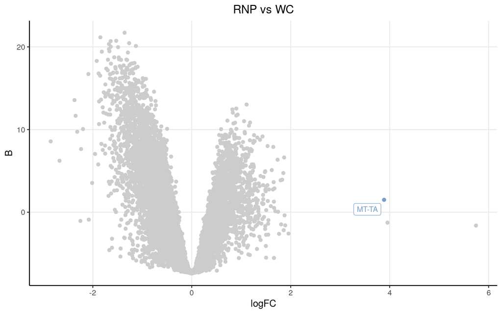

```r
upmarkers <- as.data.frame(DEGenes[DEGenes$logFC>2.5 & DEGenes$B>0,] )
downmarkers <- as.data.frame(DEGenes[DEGenes$logFC< -4 & DEGenes$B>0,] )

ggplot(data=DEGenes,
                 aes(x=logFC,
                     y=  B)) +
  geom_point(color="#CCCCCC")+
  theme_bw() +
  theme(axis.line = element_line(colour = "black"),
        panel.grid.minor = element_blank(),
        panel.border = element_blank(),
        panel.background = element_blank()) +
  ggtitle("RNP vs WC")+
  theme(plot.title = element_text(hjust = 0.5)) +
  geom_label_repel(upmarkers[1:ndegs,] , mapping=aes(label=row.names(upmarkers)[1:ndegs]),size=3,point.padding=-0.5, color="#769fca",max.overlaps = 20)+
  geom_label_repel(downmarkers[1:ndegs,] , mapping=aes(label=row.names(downmarkers)[1:ndegs]),size=3,point.padding=-0.5, color="#a2d1e6",max.overlaps = 20)+
  geom_point(data=upmarkers, aes(x=logFC, y=  B), color="#769fca")+
  geom_point(data=downmarkers, aes(x=logFC, y=  B), color="#a2d1e6")
```

```r
#write.table(DEGenes, "~/Projects/StressGranules/SGPAPER/RealSGs/Tmathenypb.txt", row.names = T)
rnp_t <- data.frame(Gene=row.names(DEGenes), rnp_t=DEGenes$t)
#pb_t <- data.frame(Gene=row.names(DEGenes), pb_t=DEGenes$t)
#sg_t <- data.frame(Gene=row.names(DEGenes), sg_t=DEGenes$t, sg_logFC=DEGenes$logFC)
```

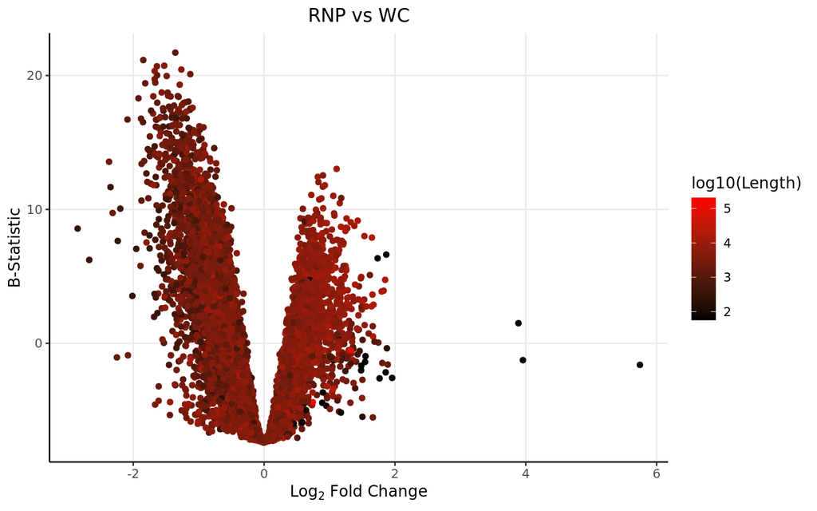

```r
DEGenes$Gene <- row.names(DEGenes)
colnames(genelength) <- c("Length","Gene")
DEGenes <- merge(DEGenes, genelength, by="Gene")

Pbody <- DEGenes[,c(1,2,4,8)]

ggplot(data=DEGenes,
                 aes(x=logFC,
                     y=  B)) +
  geom_point(aes(color=log10(Length)))+
  theme_bw() +
  theme(axis.line = element_line(colour = "black"),
        panel.grid.minor = element_blank(),
        panel.border = element_blank(),
        panel.background = element_blank()) +
  ggtitle("RNP vs WC")+ xlab(expression(Log[2] ~ Fold ~ Change)) + ylab("B-Statistic") +
  theme(plot.title = element_text(hjust = 0.5))  +
  scale_colour_gradient(low = "black", high = "red")+ theme(text=element_text(family = "Quicksand"))
```

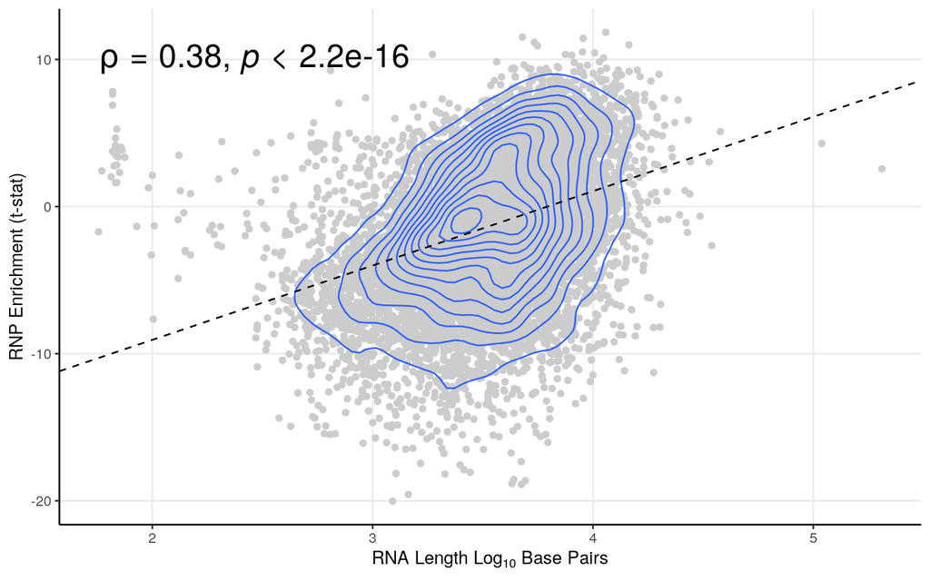

```r
smooth.SG <- lm(t~log10(Length), DEGenes)

ggplot(DEGenes, aes(y=t, x=log10(Length))) + geom_point(color="#CCCCCC", alpha=1) +   theme_bw()+ geom_density_2d()+
 ylab("RNP Enrichment (t-stat)") + xlab(expression(RNA ~ Length ~ Log[10] ~ Base ~ Pairs)) +
  theme(axis.line = element_line(colour = "black"),
        panel.grid.minor = element_blank(),
        panel.border = element_blank(),
        panel.background = element_blank()) +
  theme(plot.title = element_text(hjust = 0.5))  +
  geom_abline(slope=smooth.SG$coefficients[2], intercept = smooth.SG$coefficients[1], linetype = "dashed")+ stat_cor(method = "spearman", cor.coef.name = "rho",size=7)
```

# SG vs PB

## Linear Models

By directly comparing SGs to PBs, we get sg enrichment controlled to the method of isolation

```r
fitted <- lmFit(y, mm)
head(coef(fitted))
```

```
##           SamplePB SampleRNP SampleSG SampleWC
## 7SK      0.3585752  4.554946 5.577907 6.164172
## A1BG-AS1 3.1174872  3.066850 3.178445 2.414839
## A2M      2.7090238  3.859096 3.382536 3.295809
## AAAS     4.1105954  5.487700 4.486423 5.649326
## AACS     5.1200856  6.119243 5.051033 5.792689
## AADAT    3.0913157  4.016408 3.646845 4.040018
```

```r
#next we measure contrasts between groups (log-fold change is obtained from these fitted linear models)
contr<- makeContrasts(SampleSG       - SamplePB      , levels = colnames(coef(fitted)))

#next we estimate the contrast for each gene
tmp <- contrasts.fit(fitted, contr)


#use empirical bayes smoothing of standard erros (shrinks extreme standard erros)
tmp <- eBayes(tmp)
top.table <- topTable(tmp, sort.by = "logFC", n = Inf)
DEGenes <- top.table
ndegs=20
```

## Volcano Plots

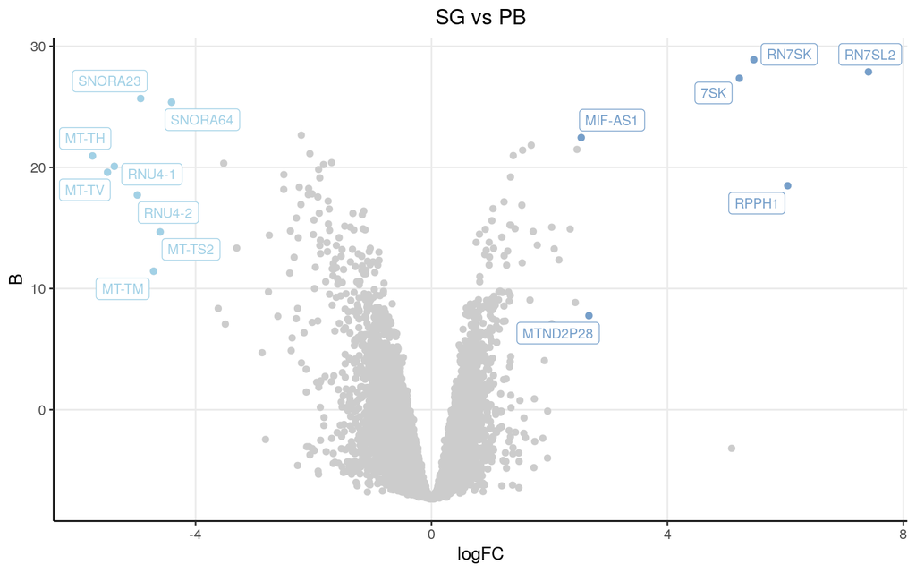

```r
upmarkers <- as.data.frame(DEGenes[DEGenes$logFC>2.5 & DEGenes$B>0,] )
downmarkers <- as.data.frame(DEGenes[DEGenes$logFC< -4 & DEGenes$B>0,] )

ggplot(data=DEGenes,
                 aes(x=logFC,
                     y=  B)) +
  geom_point(color="#CCCCCC")+
  theme_bw() +
  theme(axis.line = element_line(colour = "black"),
        panel.grid.minor = element_blank(),
        panel.border = element_blank(),
        panel.background = element_blank()) +
  ggtitle("SG vs PB")+
  theme(plot.title = element_text(hjust = 0.5)) +
  geom_label_repel(upmarkers[1:ndegs,] , mapping=aes(label=row.names(upmarkers)[1:ndegs]),size=3,point.padding=-0.5, color="#769fca",max.overlaps = 20)+
  geom_label_repel(downmarkers[1:ndegs,] , mapping=aes(label=row.names(downmarkers)[1:ndegs]),size=3,point.padding=-0.5, color="#a2d1e6",max.overlaps = 20)+
  geom_point(data=upmarkers, aes(x=logFC, y=  B), color="#769fca")+
  geom_point(data=downmarkers, aes(x=logFC, y=  B), color="#a2d1e6")
```

```r
write.table(DEGenes, "~/Projects/StressGranules/SGPAPER/RealSGs/Tmathenypb.txt", row.names = T)
#rnp_t <- data.frame(Gene=row.names(DEGenes), rnp_t=DEGenes$t)
#pb_t <- data.frame(Gene=row.names(DEGenes), pb_t=DEGenes$t)
#sg_t <- data.frame(Gene=row.names(DEGenes), sg_t=DEGenes$t, sg_logFC=DEGenes$logFC)
```

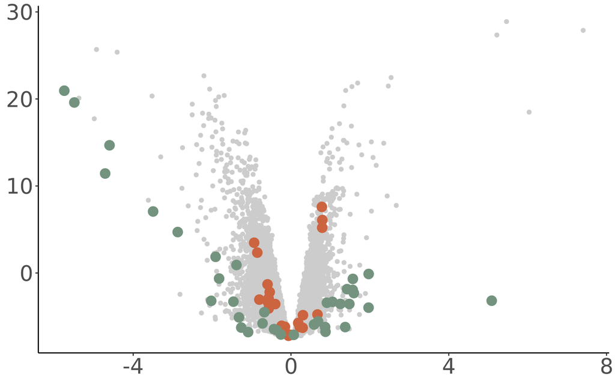

```r
MitoGenes <- fread("~/MitoGenes.txt")[[1]]
MitoData <- DEGenes[rownames(DEGenes) %in% MitoGenes, ]
NucGenes <- fread("~/rnalocate_mito_filt.csv")[[1]]
NucData <- DEGenes[rownames(DEGenes) %in% NucGenes, ]
(m <- ggplot(data=DEGenes,
                 aes(x=logFC,
                     y=B)) +
  geom_point(color="#CCCCCC") +
  geom_point(data=NucData, aes(x=logFC, y=B), color="#CB643F", size=4) +
  geom_point(data=MitoData, aes(x=logFC, y=B), color="#73937E", size=4) +
  ylab("B-Statistic") +
  xlab(expression(Log[2]~"Fold-Change")) +
  theme(
    axis.line = element_line(colour = "black"),
    panel.grid.major = element_blank(),   # remove major gridlines
    panel.grid.minor = element_blank(),   # remove minor gridlines
    panel.border = element_blank(),
    panel.background = element_blank(),
    axis.title = element_blank()
  ) +
  theme(plot.title = element_text(hjust = 0.5), plot.subtitle = element_text(hjust = 0.5)) +
  theme(text=element_text(size=25, family="Arial MS")))
```

```r
png("~/Projects/StressGranules/SGPAPER/Images/PNG/Tmat19Mito.png", width = 7, height=6, units = "in", res=300)
m
dev.off()
```

# MA Plot

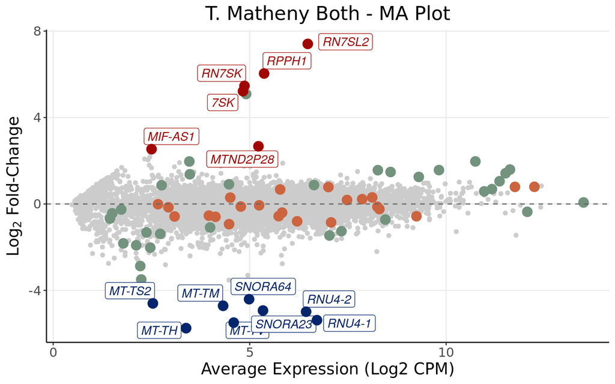

```r
# MA plot: mean expression (x) vs logFC (y), same highlighting scheme as the volcano

ggplot(data=DEGenes,
                 aes(x=AveExpr,
                     y=logFC)) +
  geom_point(color="#CCCCCC") +
  geom_point(data=MitoData, aes(x=AveExpr, y=logFC), color="#73937E", size=4) +
  geom_point(data=NucData, aes(x=AveExpr, y=logFC), color="#CB643F", size=4) +
  geom_hline(yintercept = 0, linetype="dashed", color="grey40") +
  theme_bw() + ylab(expression(Log[2]~"Fold-Change")) + xlab("Average Expression (Log2 CPM)") +
  theme(axis.line = element_line(colour = "black"),
        panel.grid.minor = element_blank(),
        panel.border = element_blank(),
        panel.background = element_blank()) +
  ggtitle("T. Matheny Both - MA Plot") +
  theme(plot.title = element_text(hjust = 0.5), plot.subtitle = element_text(hjust = 0.5)) +
  geom_label_repel(upmarkers[1:ndegs,], mapping=aes(x=AveExpr, y=logFC, label=row.names(upmarkers)[1:ndegs]), size=4, point.padding=-0.5, color="#A10702", max.overlaps=20, fontface="italic") +
  geom_label_repel(downmarkers[1:ndegs,], mapping=aes(x=AveExpr, y=logFC, label=row.names(downmarkers)[1:ndegs]), size=4, point.padding=-0.5, color="#03256C", max.overlaps=20, fontface="italic") +
  geom_point(data=upmarkers, aes(x=AveExpr, y=logFC), color="#A10702", size=4) +
  geom_point(data=downmarkers, aes(x=AveExpr, y=logFC), color="#03256C", size=4) +
  theme(text=element_text(size=15, family="Arial MS"))
```

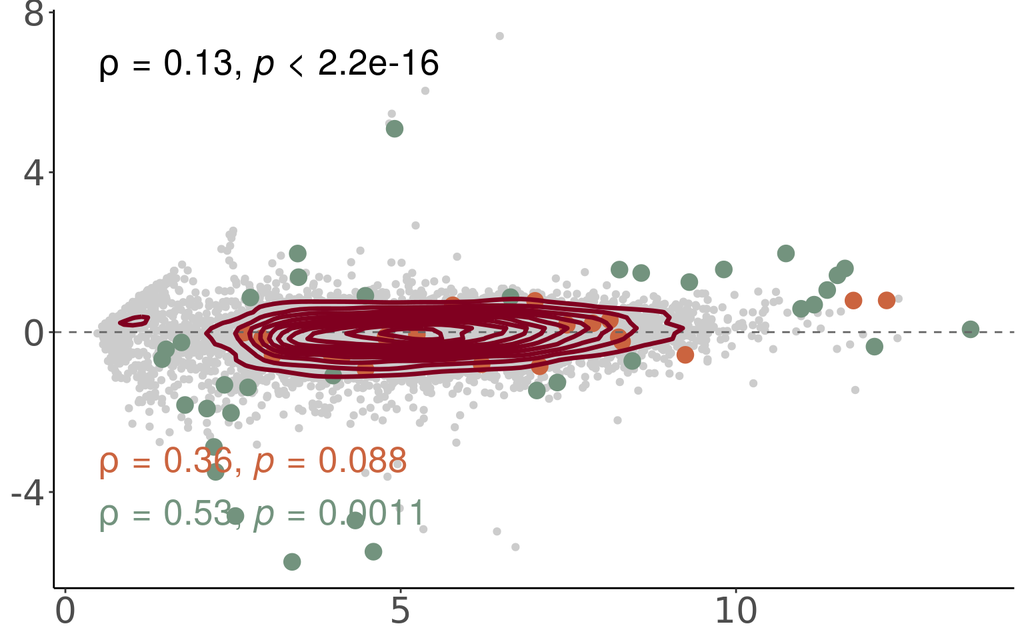

```r
# Publication-style version, stripped of axis titles, matching your "m" plot
(ma <- ggplot(data=DEGenes,
                 aes(x=AveExpr,
                     y=logFC)) +
  geom_point(color="#CCCCCC") +
  geom_point(data=MitoData, aes(x=AveExpr, y=logFC), color="#73937E", size=4) +
  geom_point(data=NucData, aes(x=AveExpr, y=logFC), color="#CB643F", size=4) +
  geom_hline(yintercept = 0, linetype="dashed", color="grey40") +
  ylab(expression(Log[2]~"Fold-Change")) +
  xlab("Average Expression (Log2 CPM)") + geom_density2d(color = "#800020", size = 1.2) + stat_cor(method = "spearman", cor.coef.name = "rho", size=7)+
  stat_cor(data = MitoData, aes(x=AveExpr, y=logFC), method = "spearman",
           cor.coef.name = "rho", size=7, color = "#73937E", label.y.npc = 0.1) +
  stat_cor(data = NucData, aes(x=AveExpr, y=logFC), method = "spearman",
           cor.coef.name = "rho", size=7, color = "#CB643F", label.y.npc = 0.2) +
  theme(
    axis.line = element_line(colour = "black"),
    panel.grid.major = element_blank(),
    panel.grid.minor = element_blank(),
    panel.border = element_blank(),
    panel.background = element_blank(),
    axis.title = element_blank()
  ) +
  theme(plot.title = element_text(hjust = 0.5), plot.subtitle = element_text(hjust = 0.5)) +
  theme(text=element_text(size=25, family="Arial MS")))
```

```r
png("~/Projects/StressGranules/SGPAPER/Images/PNG/Tmat19Mito_MA.png", width = 7, height=6, units = "in", res=300)
ma
dev.off()
```

## MA Plot

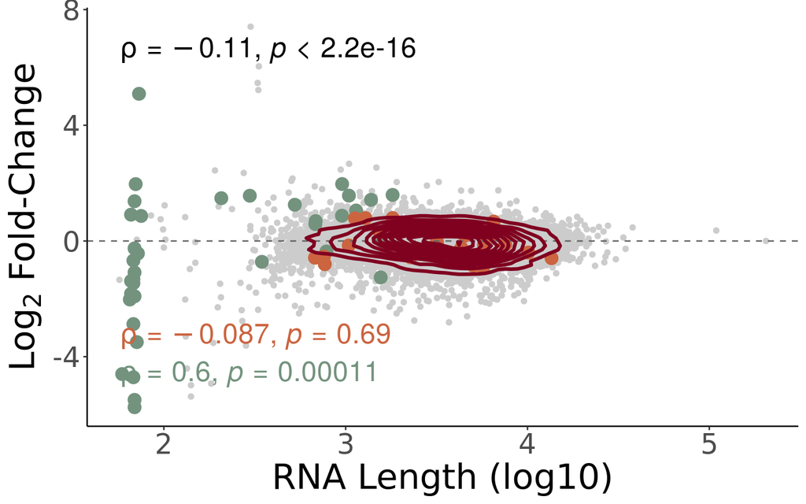

```r
MitoGenes <- fread("~/MitoGenes.txt")[[1]]

genelength <- read.csv("~/Projects/StressGranules/SG_Transcriptome/RP_Data_2021/TrimmedSamples/alignment_STAR/TranscriptLenght.txt", header=T)
genelength <- subset(genelength, Ensembl.Canonical==1)
genelength <- subset(genelength, Gene.name!="")
genelength <- genelength %>%
  group_by(Gene.name) %>%
  slice(which.max(Transcript.length..including.UTRs.and.CDS.)) %>%
  ungroup()
genelength <- genelength[,-c(2,3)]
colnames(genelength) <- c("Length", "Gene")

genelength$Cromo <- ifelse(genelength$Gene %in% MitoGenes, "Mito", "Other")

# Apply the length-based weight formula
genelength$S <- ifelse(
  genelength$Cromo == "Mito",
  (genelength$Length)^(1/3) * 3.23e-11 + 1.17e-9,   # Formula for mitochondrial RNAs
  (genelength$Length)^(1/3) * 6.09e-11 + 3.88e-10    # Formula for other RNAs
)
DEGenes$Gene <- row.names(DEGenes)
DEGenes <- merge(DEGenes, genelength, by="Gene")
MitoGenes <- fread("~/MitoGenes.txt")[[1]]
MitoData <- DEGenes[DEGenes$Gene %in% MitoGenes, ]
NucGenes <- fread("~/rnalocate_mito_filt.csv")[[1]]
NucData <- DEGenes[DEGenes$Gene %in% NucGenes, ]

# Publication-style version, stripped of axis titles, matching your "m" plot
(ma <- ggplot(data=DEGenes,
                 aes(x=log10(Length),
                     y=logFC)) +
  geom_point(color="#CCCCCC") +
  geom_point(data=MitoData, aes(x=log10(Length), y=logFC), color="#73937E", size=4) +
  geom_point(data=NucData, aes(x=log10(Length), y=logFC), color="#CB643F", size=4) +
  geom_hline(yintercept = 0, linetype="dashed", color="grey40") +
  ylab(expression(Log[2]~"Fold-Change")) + geom_density2d(color = "#800020", size = 1.2) + stat_cor(method = "spearman", cor.coef.name = "rho", size=7)+
  stat_cor(data = MitoData, aes(x=log10(Length), y=logFC), method = "spearman",
           cor.coef.name = "rho", size=7, color = "#73937E", label.y.npc = 0.1) +
  stat_cor(data = NucData, aes(x=log10(Length), y=logFC), method = "spearman",
           cor.coef.name = "rho", size=7, color = "#CB643F", label.y.npc = 0.2) +
  xlab("RNA Length (log10)") +
  theme(
    axis.line = element_line(colour = "black"),
    panel.grid.major = element_blank(),
    panel.grid.minor = element_blank(),
    panel.border = element_blank(),
    panel.background = element_blank()
  ) +
  theme(plot.title = element_text(hjust = 0.5), plot.subtitle = element_text(hjust = 0.5)) +
  theme(text=element_text(size=25, family="Arial MS")))
```

```r
png("~/Projects/StressGranules/SGPAPER/Images/PNG/Tmat19Mito_MA_length.png", width = 7, height=6, units = "in", res=300)
ma
dev.off()
```

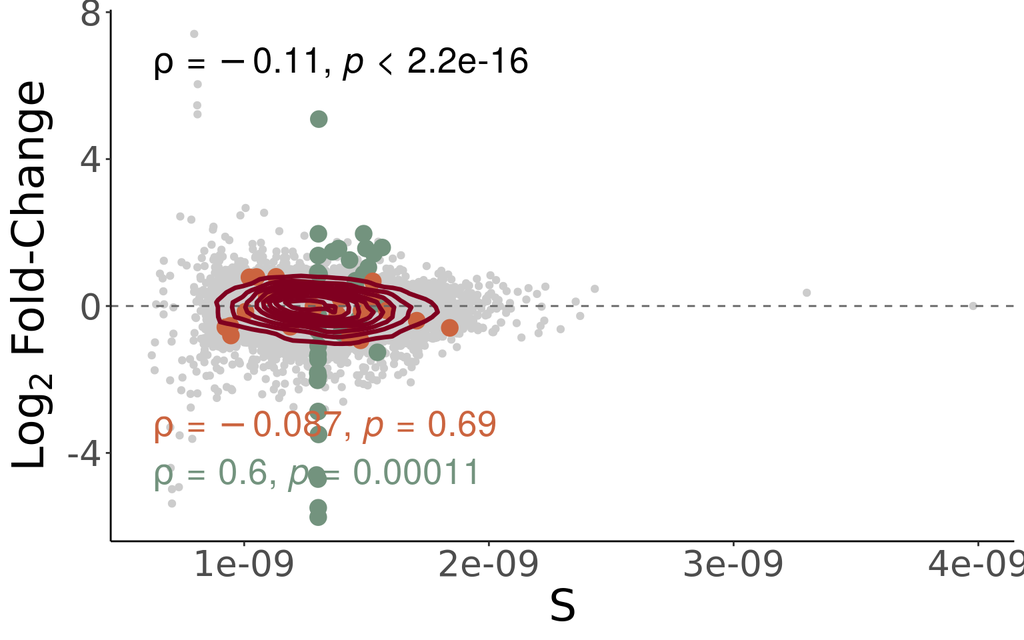

```r
# Publication-style version, stripped of axis titles, matching your "m" plot
(ma <- ggplot(data=DEGenes,
                 aes(x=(S),
                     y=logFC)) +
  geom_point(color="#CCCCCC") +
  geom_point(data=MitoData, aes(x=(S), y=logFC), color="#73937E", size=4) +
  geom_point(data=NucData, aes(x=(S), y=logFC), color="#CB643F", size=4) +
  geom_hline(yintercept = 0, linetype="dashed", color="grey40") +
  ylab(expression(Log[2]~"Fold-Change")) + geom_density2d(color = "#800020", size = 1.2) + stat_cor(method = "spearman", cor.coef.name = "rho", size=7)+
  stat_cor(data = MitoData, aes(x=S, y=logFC), method = "spearman",
           cor.coef.name = "rho", size=7, color = "#73937E", label.y.npc = 0.1) +
  stat_cor(data = NucData, aes(x=S, y=logFC), method = "spearman",
           cor.coef.name = "rho", size=7, color = "#CB643F", label.y.npc = 0.2) +
  xlab("S") +
  theme(
    axis.line = element_line(colour = "black"),
    panel.grid.major = element_blank(),
    panel.grid.minor = element_blank(),
    panel.border = element_blank(),
    panel.background = element_blank()
  ) +
  theme(plot.title = element_text(hjust = 0.5), plot.subtitle = element_text(hjust = 0.5)) +
  theme(text=element_text(size=25, family="Arial MS")))
```

```r
png("~/Projects/StressGranules/SGPAPER/Images/PNG/Tmat19Mito_MA_S.png", width = 7, height=6, units = "in", res=300)
ma
dev.off()
```

### Violins

```r
## Signature Violin (Mito/Nuc) - SG vs PB

library(data.table)
library(dplyr)
library(ggplot2)
library(rstatix)
# Restrict to just the SG and PB samples (exclude WC and RNP)
sgpb_idx <- which(sampletype %in% c("SG", "PB"))

expression.df <- y$E[, sgpb_idx]
cond <- factor(sampletype[sgpb_idx], levels = c("PB", "SG"))

custom_palette <- c(
  "PB" = "#399e5a",
  "SG" = "#769fca"
)

# ── 1. Gene sets already loaded earlier in the script (MitoGenes, NucGenes) ──
mito_genes_present <- MitoGenes[MitoGenes %in% rownames(expression.df)]
nuc_genes_present  <- NucGenes[NucGenes %in% rownames(expression.df)]
cat(length(mito_genes_present), "Mito genes found in expression matrix\n")
```

```
## 36 Mito genes found in expression matrix
```

```r
cat(length(nuc_genes_present), "Nuc genes found in expression matrix\n")
```

```
## 23 Nuc genes found in expression matrix
```

```r
# ── 2. Rank all genes per sample (1 = least expressed) ───────────────────────
rank_matrix <- apply(expression.df, 2, function(x) rank(x, ties.method = "average"))
rank_matrix <- as.data.frame(rank_matrix)

# ── 3. Compute a rank-sum score per sample, one gene set at a time ───────────
compute_score <- function(genes, rank_matrix, n_total) {
  colSums(rank_matrix[genes, , drop = FALSE]) / n_total
}

mito_score <- compute_score(mito_genes_present, rank_matrix, nrow(expression.df))
nuc_score  <- compute_score(nuc_genes_present, rank_matrix, nrow(expression.df))

# ── 4. Assemble plot dataframe, long format across both gene sets ────────────
score_df <- rbind(
  data.frame(Sample = colnames(expression.df), Score = as.numeric(mito_score),
             Condition = cond, GeneSet = "Mito"),
  data.frame(Sample = colnames(expression.df), Score = as.numeric(nuc_score),
             Condition = cond, GeneSet = "Nuc")
)

# ── 5. Statistics per gene set: one-way ANOVA (equivalent to t-test, 2 groups) ──
stat_labels <- score_df %>%
  group_by(GeneSet) %>%
  group_modify(~{
    aov_res  <- aov(Score ~ Condition, data = .x)
    aov_tidy <- summary(aov_res)
    p_raw  <- aov_tidy[[1]][["Pr(>F)"]][1]
    p_adj  <- p.adjust(p_raw, method = "BH")
    ss_between <- aov_tidy[[1]][["Sum Sq"]][1]
    ss_total   <- sum(aov_tidy[[1]][["Sum Sq"]])
    eta_sq     <- ss_between / ss_total
    cohens_f   <- sqrt(eta_sq / (1 - eta_sq))
    data.frame(
      label = paste0("Cohen's f = ", round(cohens_f, 3),
                      "\nadj. p = ", formatC(p_adj, format = "e", digits = 2))
    )
  })

# ── 6. Plot ───────────────────────────────────────────────────────────────────
vilsigplot <- ggplot(score_df, aes(x = Condition, y = Score, fill = Condition)) +
  geom_violin(colour = "black", alpha = 0.6, trim = FALSE) +
  geom_point(
    position = position_jitter(width = 0.1),
    alpha    = 0.7,
    size     = 1.5
  ) +
  stat_summary(fun = mean,   geom = "point", shape = 18,
               size = 3, colour = "black") +
  stat_summary(fun = median, geom = "point", shape = 17,
               size = 3, colour = "black") +
  geom_text(
    data  = stat_labels,
    aes(x = -Inf, y = Inf, label = label),
    hjust = -0.05, vjust = 1.2,
    size  = 4, fontface = "bold", lineheight = 1.1,
    inherit.aes = FALSE
  ) +
  facet_wrap(~GeneSet, scales = "free_y") +
  scale_fill_manual(values = custom_palette) +
  labs(
    x     = "Fraction",
    y     = "Signature Score (Rank Sum)",
    title = "Mitochondrial vs Nuclear-Localized Gene Scores - SG vs PB (Tmat19)"
  ) +
  theme_bw() +
  theme(
    plot.title      = element_text(hjust = 0.5, size = 14, face = "bold"),
    axis.text.x     = element_text(size = 12),
    strip.text      = element_text(size = 12, face = "bold"),
    legend.position = "none"
  )

png("~/Projects/StressGranules/SGPAPER/Images/PNG/Tmat19SGvsPB_MitoSigs.png", width = 14, height=6, units = "in", res=300)
vilsigplot
dev.off()
```

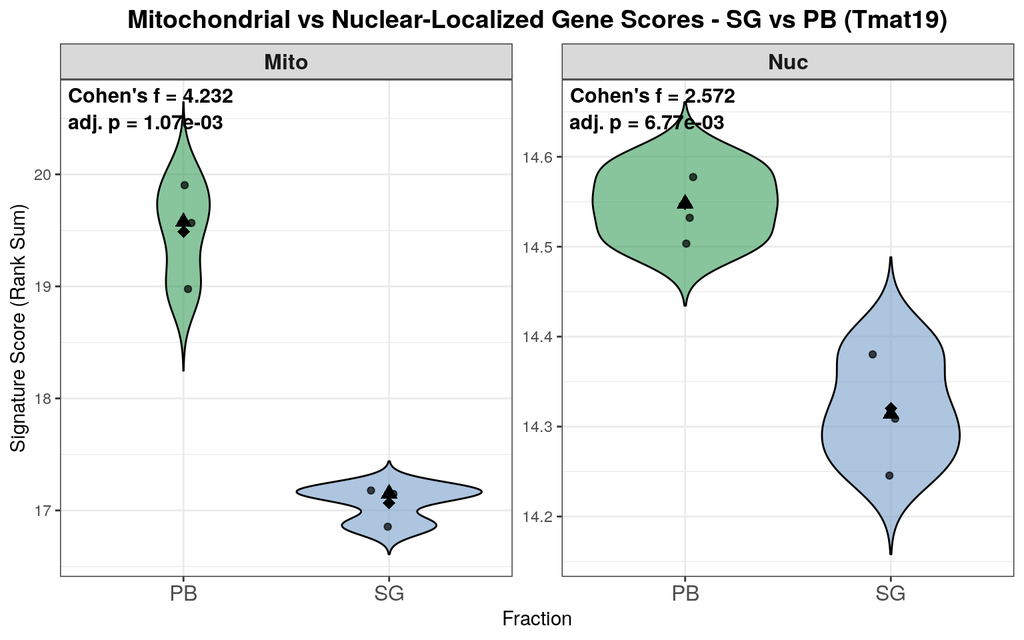

```r
vilsigplot
```

# GSEA

### For Mito

```r
### For Mito

DEGenes_SG.vs.PB <- DEGenes
# --- Rank genes by t-statistic as usual ---
DEGenes_SG.vs.PB <- DEGenes_SG.vs.PB[order(DEGenes_SG.vs.PB$t),]
gseatool <- data.frame(Symbol = DEGenes_SG.vs.PB$Gene, t = DEGenes_SG.vs.PB$t)
vectorranks <- gseatool$t
names(vectorranks) <- gseatool$Symbol

# ... rest unchanged ...

# --- Define MitoGenes as a custom gene set ---
MitoGenes <- fread("~/MitoGenes.txt")[[1]]
custom.gsets <- list(MitoGenes = toupper(MitoGenes))

# --- Run fgsea ---
mito.res <- fgsea(pathways = custom.gsets,
                  stats = vectorranks)
```

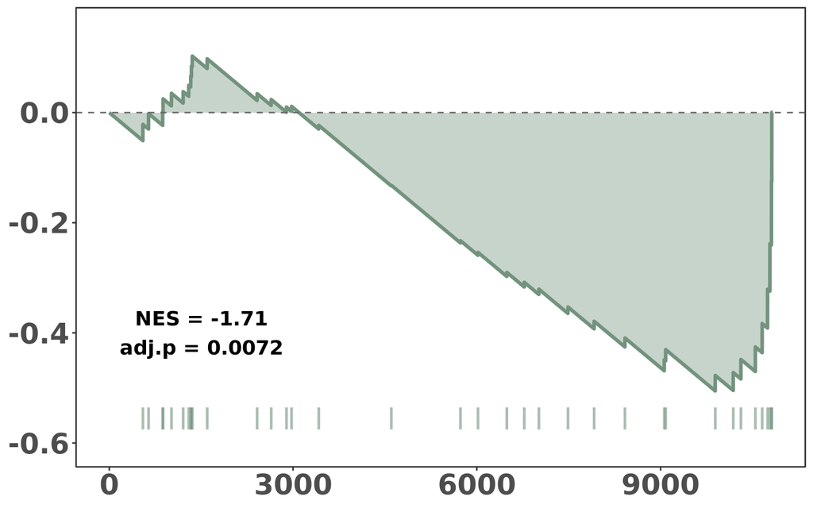

```r
mito.plot.base <- plotEnrichment(custom.gsets[["MitoGenes"]], vectorranks)
curve.data <- mito.plot.base$data

# --- key fix: match the curve's internal descending order ---
ord <- order(vectorranks, decreasing = TRUE)
ranked.names <- names(vectorranks)[ord]
gene.positions <- which(ranked.names %in% custom.gsets[["MitoGenes"]])

rug.top    <- min(curve.data$y) - 0.03
rug.bottom <- rug.top - 0.04

y.min <- rug.bottom - 0.03
y.max <- max(curve.data$y) + 0.05

(mito.plot <- ggplot(curve.data, aes(x = x, y = y)) +
  geom_area(fill = "#73937E", alpha = 0.4) +
  geom_line(color = "#73937E", linewidth = 1.2) +
  geom_hline(yintercept = 0, linetype = "dashed", color = "grey40") +
  geom_segment(data = data.frame(x = gene.positions),
               aes(x = x, xend = x, y = rug.top, yend = rug.bottom),
               color = "#73937E", alpha = 0.6, linewidth = 0.9,
               inherit.aes = FALSE) +
  annotate("text", x = 1500, y = -0.4,
           label = paste0("NES = ", round(mito.res$NES, 2),
                          "\nadj.p = ", round(mito.res$padj, 4)),
           size = 5, family = "Arial MS", fontface = "bold") +
  coord_cartesian(ylim = c(y.min, y.max), clip = "off") +
  theme_bw() +
  theme(text = element_text(size = 25, family = "Arial MS"),
        plot.title = element_text(hjust = 0.5, face = "bold"),
        axis.title = element_blank(),
        axis.text = element_text(face = "bold"),
        panel.grid.minor = element_blank(),
        panel.grid.major = element_blank()))
```

```r
png("~/Projects/StressGranules/SGPAPER/Images/PNG/MitoGSEA_Tmat19.png", width=7, height=6, units="in", res=300)
mito.plot
dev.off()
```

### For Nuc

```r
### For Mito

DEGenes_SG.vs.PB <- DEGenes
# --- Rank genes by t-statistic as usual ---
DEGenes_SG.vs.PB <- DEGenes_SG.vs.PB[order(DEGenes_SG.vs.PB$t),]
gseatool <- data.frame(Symbol = DEGenes_SG.vs.PB$Gene, t = DEGenes_SG.vs.PB$t)
vectorranks <- gseatool$t
names(vectorranks) <- gseatool$Symbol

# ... rest unchanged ...

# --- Define MitoGenes as a custom gene set ---
MitoGenes <- fread("~/rnalocate_mito_filt.csv")[[1]]
custom.gsets <- list(MitoGenes = toupper(MitoGenes))

# --- Run fgsea ---
mito.res <- fgsea(pathways = custom.gsets,
                  stats = vectorranks)
```

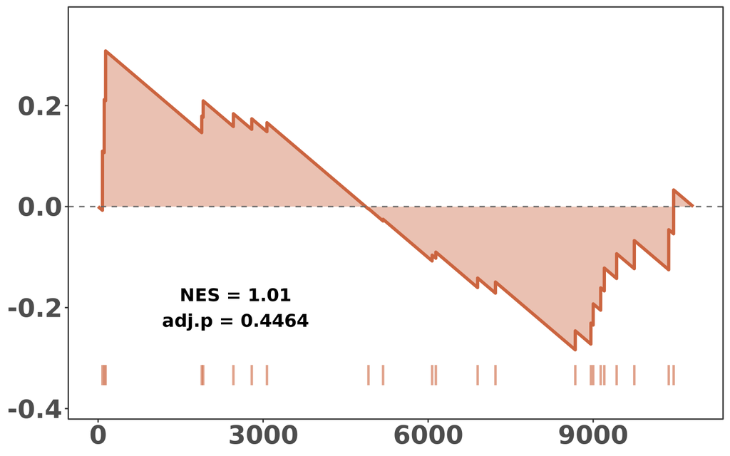

```r
mito.plot.base <- plotEnrichment(custom.gsets[["MitoGenes"]], vectorranks)
curve.data <- mito.plot.base$data

# --- key fix: match the curve's internal descending order ---
ord <- order(vectorranks, decreasing = TRUE)
ranked.names <- names(vectorranks)[ord]
gene.positions <- which(ranked.names %in% custom.gsets[["MitoGenes"]])

rug.top    <- min(curve.data$y) - 0.03
rug.bottom <- rug.top - 0.04

y.min <- rug.bottom - 0.03
y.max <- max(curve.data$y) + 0.05

(mito.plot <- ggplot(curve.data, aes(x = x, y = y)) +
  geom_area(fill = "#CB643F", alpha = 0.4) +
  geom_line(color = "#CB643F", linewidth = 1.2) +
  geom_hline(yintercept = 0, linetype = "dashed", color = "grey40") +
  geom_segment(data = data.frame(x = gene.positions),
               aes(x = x, xend = x, y = rug.top, yend = rug.bottom),
               color = "#CB643F", alpha = 0.6, linewidth = 0.9,
               inherit.aes = FALSE) +
  annotate("text", x = 2500, y = -0.2,
           label = paste0("NES = ", round(mito.res$NES, 2),
                          "\nadj.p = ", round(mito.res$padj, 4)),
           size = 5, family = "Arial MS", fontface = "bold") +
  coord_cartesian(ylim = c(y.min, y.max), clip = "off") +
  theme_bw() +
  theme(text = element_text(size = 25, family = "Arial MS"),
        plot.title = element_text(hjust = 0.5, face = "bold"),
        axis.title = element_blank(),
        axis.text = element_text(face = "bold"),
        panel.grid.minor = element_blank(),
        panel.grid.major = element_blank()))
```

```r
png("~/Projects/StressGranules/SGPAPER/Images/PNG/NucGSEA_TMat19.png", width=7, height=6, units="in", res=300)
mito.plot
dev.off()
```

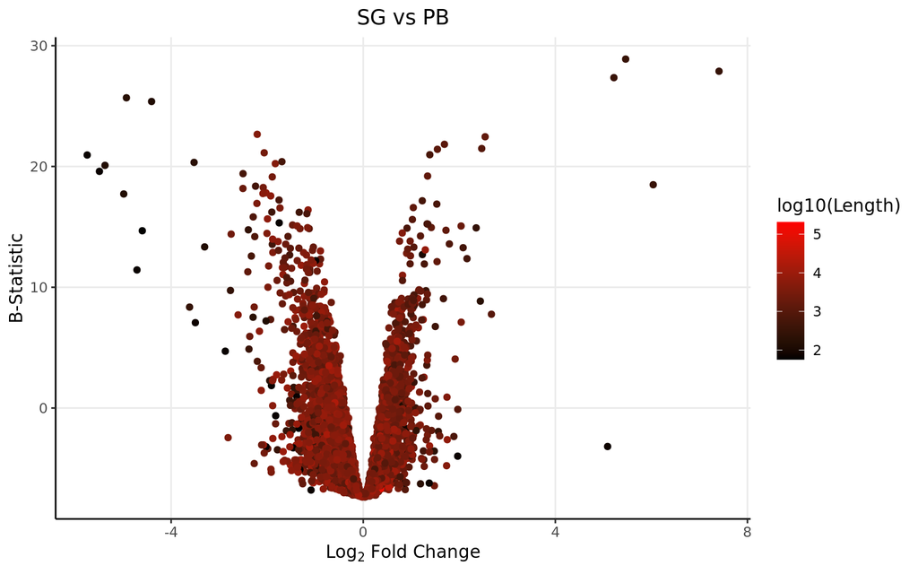

```r
Pbody <- DEGenes[,c(1,2,4,8)]

ggplot(data=DEGenes,
                 aes(x=logFC,
                     y=  B)) +
  geom_point(aes(color=log10(Length)))+
  theme_bw() +
  theme(axis.line = element_line(colour = "black"),
        panel.grid.minor = element_blank(),
        panel.border = element_blank(),
        panel.background = element_blank()) +
  ggtitle("SG vs PB")+ xlab(expression(Log[2] ~ Fold ~ Change)) + ylab("B-Statistic") +
  theme(plot.title = element_text(hjust = 0.5))  +
  scale_colour_gradient(low = "black", high = "red")+ theme(text=element_text(family = "Quicksand"))
```

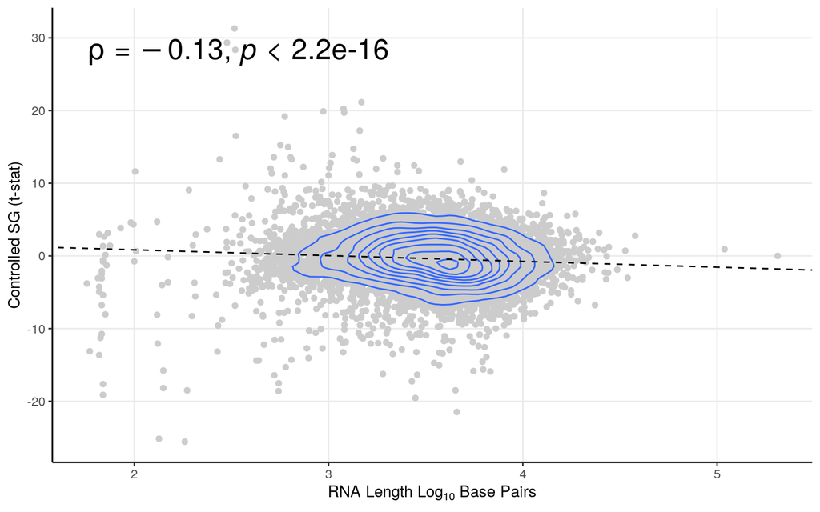

```r
smooth.SG <- lm(t~log10(Length), DEGenes)

ggplot(DEGenes, aes(y=t, x=log10(Length))) + geom_point(color="#CCCCCC", alpha=1) +   theme_bw()+ geom_density_2d()+
 ylab("Controlled SG (t-stat)") + xlab(expression(RNA ~ Length ~ Log[10] ~ Base ~ Pairs)) +
  theme(axis.line = element_line(colour = "black"),
        panel.grid.minor = element_blank(),
        panel.border = element_blank(),
        panel.background = element_blank()) +
  theme(plot.title = element_text(hjust = 0.5))  +
  geom_abline(slope=smooth.SG$coefficients[2], intercept = smooth.SG$coefficients[1], linetype = "dashed")+ stat_cor(method = "spearman", cor.coef.name = "rho",size=7)
```

## Intra Comparisons

Now, I repeat the same comparisons as before.

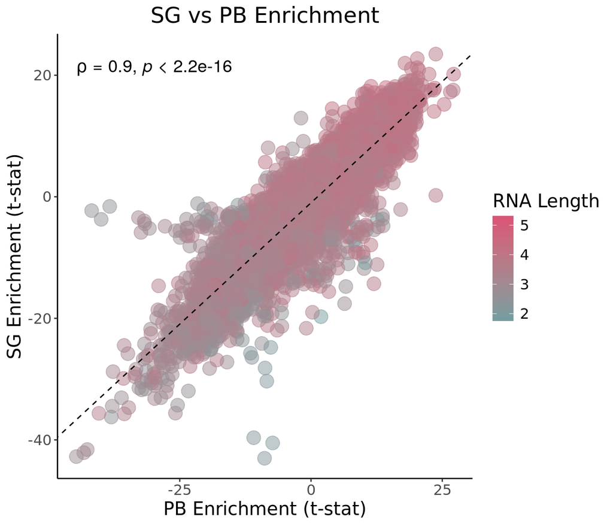

```r
tstable <- merge(rnp_t, pb_t, by="Gene")
tstable <- merge(tstable, sg_t, by="Gene")



tstable <- merge(tstable, genelength, by="Gene")
smooth.SG <- lm(sg_t~(pb_t), tstable)

# Calculate the Spearman correlation coefficient
spearman_corr <- cor(tstable$sg_t, (tstable$pb_t), method = "spearman")

ggplot(tstable, aes(y=sg_t, x=(pb_t))) + geom_point(aes(color=log10(Length)), alpha=0.5, size=5) +   theme_bw()+
 ylab("SG Enrichment (t-stat)") + xlab("PB Enrichment (t-stat)") + scale_colour_gradient(low="black", high = "Red")+
  theme(axis.line = element_line(colour = "black"),
        panel.grid.minor = element_blank(),
        panel.border = element_blank(),
        panel.background = element_blank()) +
  geom_abline(slope=smooth.SG$coefficients[2], intercept = smooth.SG$coefficients[1], linetype = "dashed")+
  theme(plot.title = element_text(hjust = 0.5))  + ggtitle("SG vs PB Enrichment")+
  scale_colour_gradient(low="#729EA1", high = "#DB5375")+
  labs(colour = "RNA Length") + stat_cor(method = "spearman", cor.coef.name = "rho", size=5)+ theme(panel.grid.major = element_blank(), panel.grid.minor = element_blank())+theme(text=element_text(size=15,  family="Arial MS"))
```

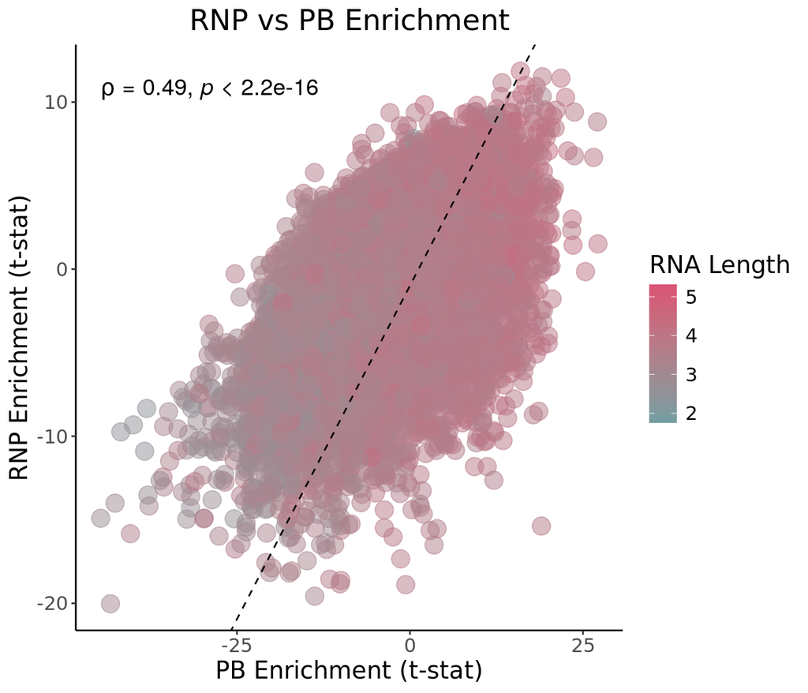

```r
smooth.SG <- lm(sg_t~(pb_t), tstable)

# Calculate the Spearman correlation coefficient
spearman_corr <- cor(tstable$rnp_t, (tstable$pb_t), method = "spearman")

ggplot(tstable, aes(y=rnp_t, x=(pb_t))) + geom_point(aes(color=log10(Length)), alpha=0.5, size=5) +   theme_bw()+
 ylab("RNP Enrichment (t-stat)") + xlab("PB Enrichment (t-stat)") + scale_colour_gradient(low="black", high = "Red")+
  theme(axis.line = element_line(colour = "black"),
        panel.grid.minor = element_blank(),
        panel.border = element_blank(),
        panel.background = element_blank()) +
  geom_abline(slope=smooth.SG$coefficients[2], intercept = smooth.SG$coefficients[1], linetype = "dashed")+
  theme(plot.title = element_text(hjust = 0.5))  + ggtitle("RNP vs PB Enrichment")+
  scale_colour_gradient(low="#729EA1", high = "#DB5375")+
  labs(colour = "RNA Length") + stat_cor(method = "spearman", cor.coef.name = "rho", size=5)+ theme(panel.grid.major = element_blank(), panel.grid.minor = element_blank())+theme(text=element_text(size=15,  family="Arial MS"))
```

And once again, we get same results.

# Pbody Isolation by another method

To ascertain if the similar signal between SGs and PBs can be explained by the method of isolation, I will use another study, that isolates PBs through a different method. However, these PBs are not stressed.

```r
#The study features 2 different cell lines
newpbody1 <- fread("~/Projects/StressGranules/SG_Transcriptome/P_Bodies/GSE224752_HEL_Counts.txt")
colnames(newpbody1) <- c("Gene","HPB1", "HPB2", "HCY1", "HCY2")
newpbody2 <- fread("~/Projects/StressGranules/SG_Transcriptome/P_Bodies/GSE224752_MOLM13_Counts.txt.gz")
colnames(newpbody2) <- c("Gene","MCY1", "MCY2", "MPB1", "MPB2")


read.counts1 <- newpbody1 %>%
  group_by(Gene) %>%
  summarise(across(everything(), sum, na.rm = TRUE))

read.counts2 <- newpbody2 %>%
  group_by(Gene) %>%
  summarise(across(everything(), sum, na.rm = TRUE))

newpbody <- merge(read.counts1, read.counts2, by="Gene")

read.counts <- as.data.frame(newpbody)

row.names(read.counts) <- read.counts$Gene #changes rownames into hgnc symbols
read.counts$Gene <- NULL
```

## Extra Quality Control

Let’s check for sample complexity. It is possible that one or more samples have different complexity. In specific, I am going to check if enough reads have been obtained from every sample. If not, we should have a great bias to housekeeping genes. Another way to put it, is to say that even with all reads, we won’t obtain a great deal of different genes.

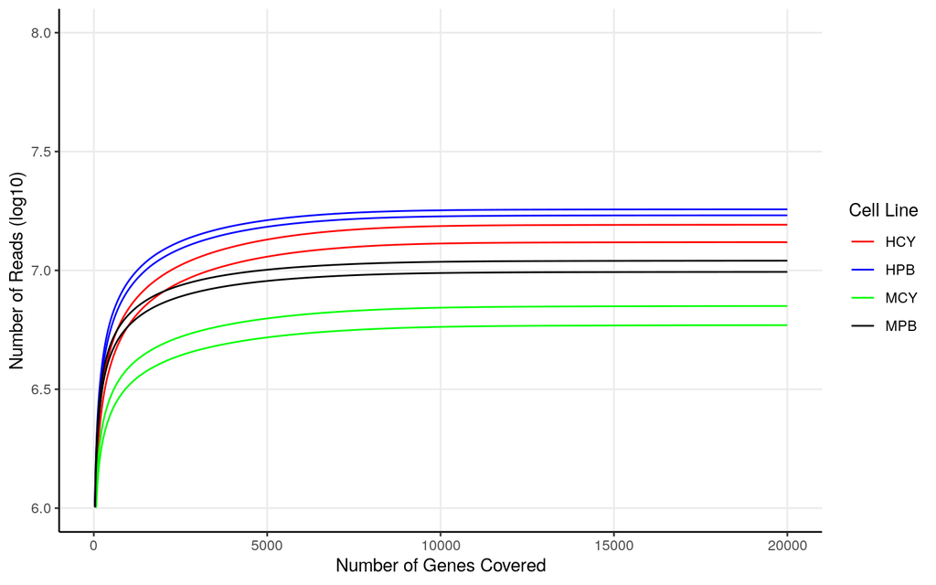

```r
# Define color palette
custom_palette <- c("red", "blue", "green", "black")

# Variable that I wish to colour
SampleColouring <- c(rep("HPB",2), rep("HCY",2), rep("MCY",2), rep("MPB", 2))

# Build cumulative counts
final <- sapply(1:ncol(read.counts), function(i) {
  sort_vals <- read.counts[order(read.counts[, i], decreasing = TRUE), i]
  cumsum(sort_vals)
})
final <- as.data.frame(final)
colnames(final) <- colnames(read.counts)

# Melt and add gene position + sample info
finalmelt <- reshape2::melt(final, variable.name = "Sample")
finalmelt$genes <- rep(1:nrow(final), times = ncol(final))
finalmelt$SampleColouring <- rep(SampleColouring, each = nrow(final))

# Plot cumulative read coverage
ggplot(data = finalmelt, aes(x = genes, y = log10(value), group = Sample, color = SampleColouring)) +
  geom_line() +
  scale_color_manual(values = custom_palette, name = "Cell Line") +
  theme_bw() +
  xlab("Number of Genes Covered") +
  ylab("Number of Reads (log10)") +
  xlim(0, 20000) +
  ylim(6, 8) +
  theme(
    axis.line = element_line(colour = "black"),
    panel.grid.minor = element_blank(),
    panel.border = element_blank(),
    panel.background = element_blank()
  )
```

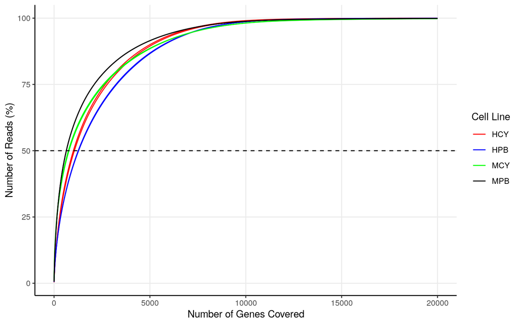

```r
# Create percentage-based plot
orderfinal <- subset(finalmelt, genes == max(finalmelt$genes))
trial <- merge(orderfinal[, c("Sample", "value")], finalmelt, by = "Sample", suffixes = c(".total", ".current"))
trial$percent <- (trial$value.current / trial$value.total) * 100
trial$SampleColouring <- rep(SampleColouring, each = nrow(final))

ggplot(data = trial, aes(x = genes, y = percent, group = Sample, color = SampleColouring)) +
  geom_line() +
  geom_hline(yintercept = 50, linetype = "dashed") +
  scale_color_manual(values = custom_palette, name = "Cell Line") +
  xlab("Number of Genes Covered") +
  ylab("Number of Reads (%)") +
  xlim(0, 20000) +
  theme_bw() +
  theme(
    axis.line = element_line(colour = "black"),
    panel.grid.minor = element_blank(),
    panel.border = element_blank(),
    panel.background = element_blank()
  )
```

As we can see in these plots, there are some differences in accordance to sample type. Nevertheless, no individual sample behaves vastly different than its same type counterparts, so we can proceed.

## Filtration

### *Before Filtration*

Let us begin with the filtration. Before moving on, it is important to note that according to the authors, these RNA granules are not pure and contain several contaminants.

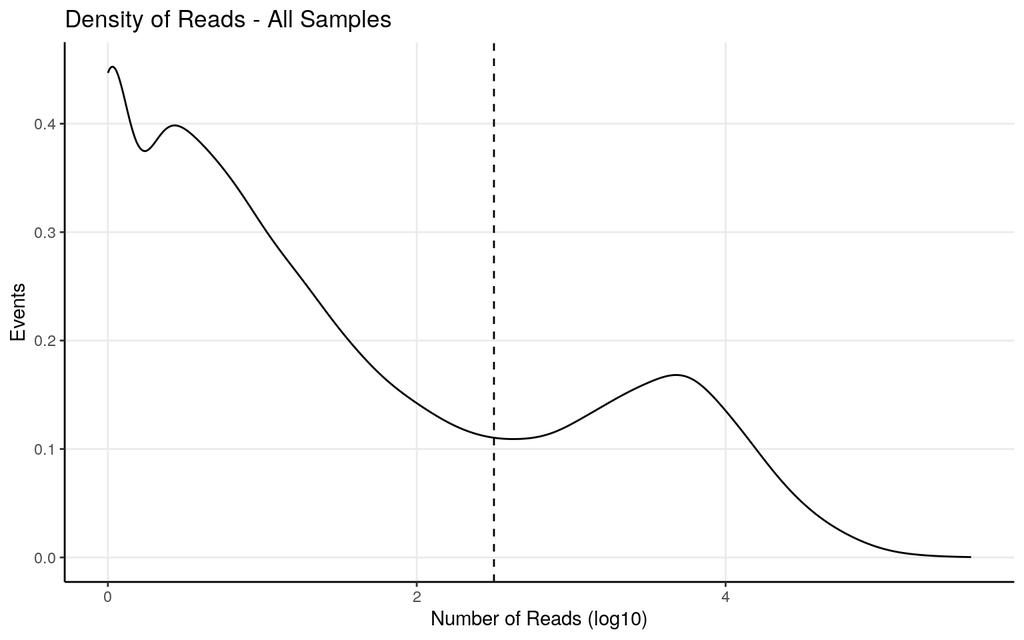

```r
alternew <- log10(rowSums(read.counts))
alternew <- as.data.frame(alternew)

ggplot(alternew, aes(x=alternew)) + geom_density() + theme_bw() + geom_vline(xintercept = 2.5, linetype = "dashed") + ylab("Events") + xlab("Number of Reads (log10)") +
  theme(axis.line = element_line(colour = "black"),
        panel.grid.minor = element_blank(),
        panel.border = element_blank(),
        panel.background = element_blank()) + ggtitle("Density of Reads - All Samples")
```

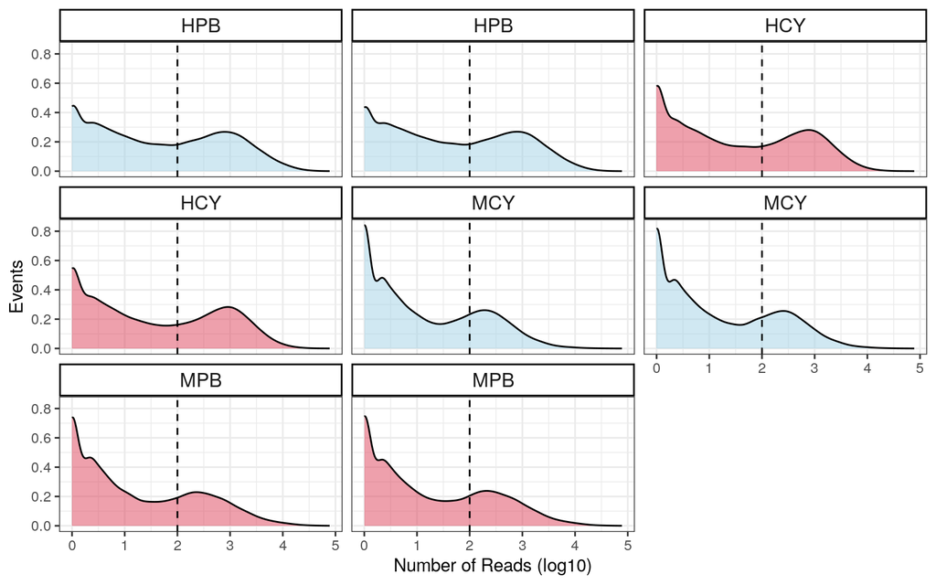

```r
dffordensy <- read.counts
sampnamer <- SampleColouring
names(sampnamer) <- colnames(dffordensy)
dffordensy <- reshape2::melt(t(dffordensy))
colnames(dffordensy) <- c("Sample", "Gene", "Expression")

densyplot <- ggplot(dffordensy, aes(x=log10(Expression), group=Sample, fill=Sample)) + geom_density(alpha=0.5) + facet_wrap(.~Sample, ncol=3, labeller = labeller(Sample=sampnamer))
densyplot <- densyplot + scale_fill_manual(name = "Sample Type", values = c("#a2d1e6", "#a2d1e6", "#de425b", "#de425b","#a2d1e6", "#a2d1e6", "#de425b", "#de425b"))
densyplot <- densyplot + theme_bw() + xlab("Number of Reads (log10)") + ylab("Events") + theme(legend.position = "none")
densyplot + geom_vline(xintercept = 2, linetype = "dashed") + theme(
      strip.text.x = element_text(
        size = 12
        )) +
 theme(
   strip.background = element_rect(
     color="black", fill="#FFFFFF", size=1, linetype="solid"
     )
   )
```

### *After Filtration*

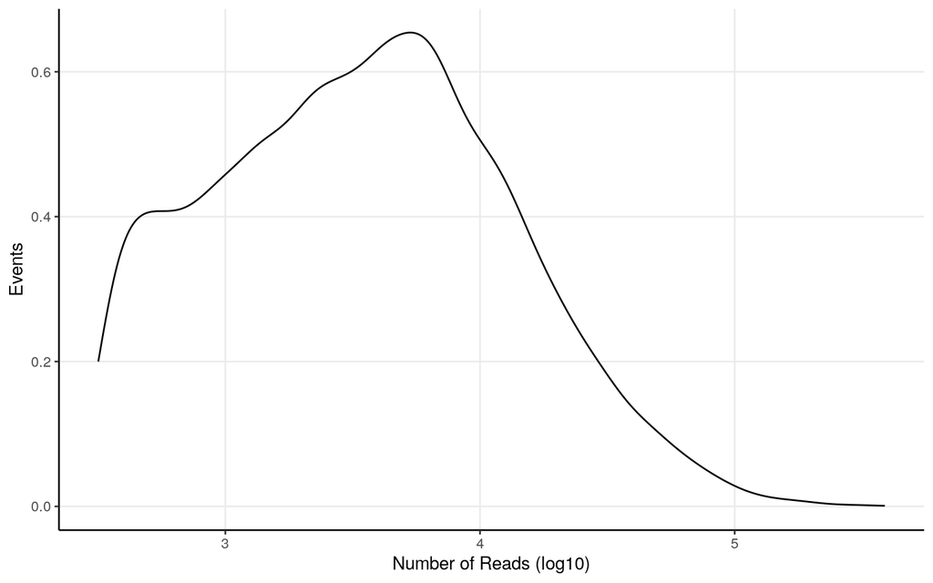

```r
filterednew <- subset(read.counts, alternew>2.5)

#after cutting, its a good idea to visualize again
falternew <- log10(rowSums(filterednew))
falternew <- as.data.frame(falternew)
ggplot(falternew, aes(x=falternew)) + geom_density() + theme_bw() + ylab("Events") + xlab("Number of Reads (log10)") +
  theme(axis.line = element_line(colour = "black"),
        panel.grid.minor = element_blank(),
        panel.border = element_blank(),
        panel.background = element_blank())
```

```r
#lets save the genes which we maintain
impgenes <- c(row.names(falternew))


#Now we need to select only the rows which have those genes.
finaltable <- read.counts[row.names(read.counts)%in%impgenes,]
```

## Matrices

Good! Now we can proceed by designing our matrices.

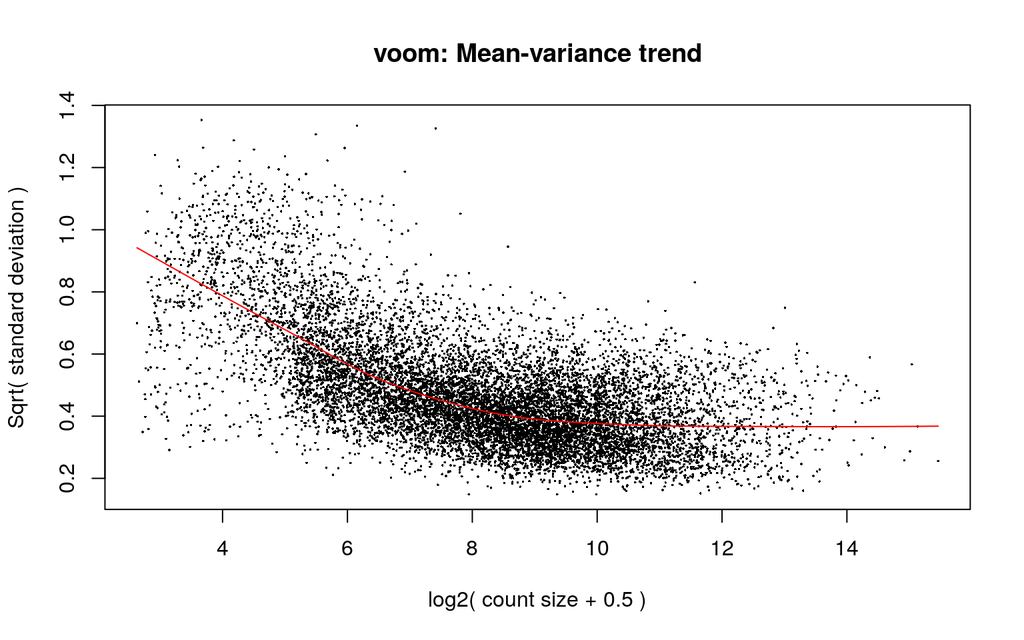

```r
#To be able to use Voom, we must first convert our read count table into a special DGE object.
D0 <- DGEList(finaltable)

#for the others, we need to select only relevant columns.

#Then we calculate the normalization factors.
#Bear in mind this step calculates the normalization factors, but does not normalize itself.
D0 <- calcNormFactors(D0)


sampletype <- c("PB","PB", "CY", "CY","CY","CY", "PB", "PB")
celltype <- c("HEL","HEL","HEL","HEL","ML","ML","ML","ML")

metadata <- data.frame(Sample=sampletype, Cell=celltype)

#Now we do our matrix itself
mm <- model.matrix(~0+Sample+Cell, metadata)

#and now we normalize. This step also turns our counts into log2-counts per million.
y <- voom(D0, mm, plot = T)
```

## Normalisation

For normalisation I convert the read counts into log2CPMs. Its a good way to visualise how the reads are.

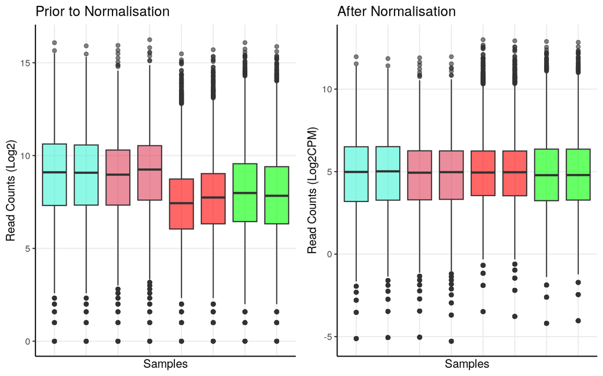

```r
dfforboxy <- finaltable

orderforplots <- sampnamer
colouring <- data.frame(Sample=colnames(dfforboxy), Types=orderforplots)
dfforboxy <- reshape2::melt(dfforboxy)
colnames(dfforboxy) <- c("Sample", "Expression")
dfforboxy <- merge(dfforboxy, colouring, by="Sample")
prenorm <- ggplot(dfforboxy, aes(x=Sample, y=(log2(Expression+1)), fill=Types)) + geom_boxplot(alpha=0.6) + theme_bw() + ylab("Read Counts (Log2)") + xlab("Samples") + scale_fill_manual(name = "Sample Type", values = c("#43F3D5", "#de425b", "red", "green"), labels=unique(sampnamer), breaks =unique(sampnamer)) +
  theme(axis.line = element_line(colour = "black"),
        panel.grid.minor = element_blank(),
        panel.border = element_blank(),
        panel.background = element_blank(),
        axis.text.x=element_blank(),
        axis.ticks.x=element_blank(),
        legend.position = "None") + ggtitle("Prior to Normalisation")

dfforboxy <- y$E
dfforboxy <- reshape2::melt(dfforboxy)
dfforboxy <- dfforboxy[,-1]
colnames(dfforboxy) <- c("Sample", "Expression")
dfforboxy <- merge(dfforboxy, colouring, by="Sample")
postnorm <- ggplot(dfforboxy, aes(x=Sample, y=Expression, fill=Types)) + geom_boxplot(alpha=0.6) + theme_bw() + ylab("Read Counts (Log2CPM)") + xlab("Samples") + scale_fill_manual(name = "Sample Type", values = c("#43F3D5","#de425b", "red", "green"), labels=unique(sampnamer), breaks =unique(sampnamer)) +
  theme(axis.line = element_line(colour = "black"),
        panel.grid.minor = element_blank(),
        panel.border = element_blank(),
        panel.background = element_blank(),
        axis.text.x=element_blank(),
        axis.ticks.x=element_blank(),
        legend.position = "None") + ggtitle("After Normalisation")

ggarrange(prenorm, postnorm, nrow=1)
```

## PCA

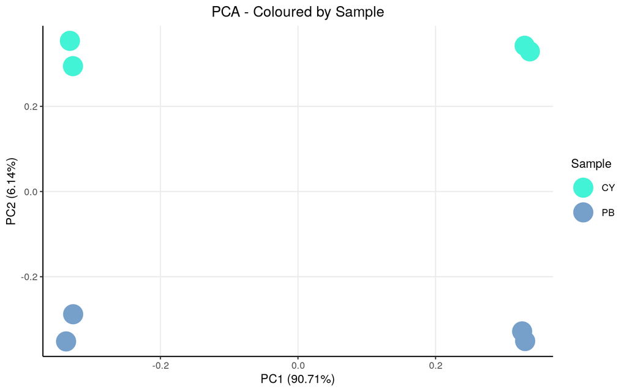

```r
#In here, I am just defining some colours to use
custom_palette <- c("#43F3D5", "#769fca", "#e88184", "#de425b")

#This prepares my data for the PCA
dfforpca <- y$E
dfforpca <- t(dfforpca)
dfforpca <- as.data.frame(dfforpca) # needs to be a data.frame
dfforpca <- apply(dfforpca, 2, as.numeric) # Ensure numeric
dfforpca <- as.data.frame(dfforpca) # still needs to be a data.frame

# Add metadata, which we will then use to plot
dfforpca$Sample <- sampletype
dfforpca$Cell <- celltype

# PCA computation itself. I do one PCA for each variable I want to see.
pca_res <- prcomp(dfforpca[, 1:(ncol(dfforpca)-2)], scale = FALSE)

p_Sample <- autoplot(pca_res, data = dfforpca, x = 1, y = 2, colour = "Sample", size = 8) +
  theme_bw() +
  scale_colour_manual(name = "Sample", values = custom_palette) +
  ggtitle("PCA - Coloured by Sample") +
  theme(plot.title = element_text(hjust = 0.5),
        axis.line = element_line(colour = "black"),
        panel.grid.minor = element_blank(),
        panel.border = element_blank(),
        panel.background = element_blank())

p_cell <- autoplot(pca_res, data = dfforpca, x = 1, y = 2, colour = "Cell", size = 8) +
  theme_bw() +
  scale_colour_manual(name = "Cell", values = custom_palette) +
  ggtitle("PCA - Coloured by Cell") +
  theme(plot.title = element_text(hjust = 0.5),
        axis.line = element_line(colour = "black"),
        panel.grid.minor = element_blank(),
        panel.border = element_blank(),
        panel.background = element_blank())

p_Sample
```

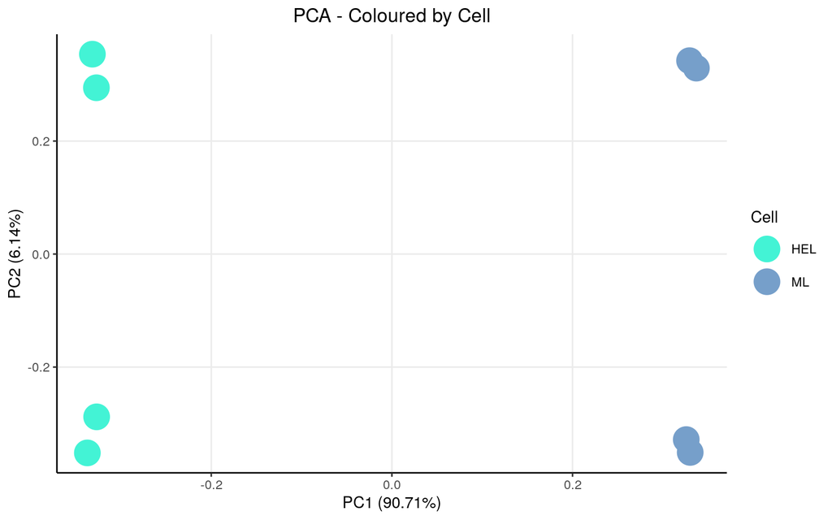

```r
p_cell
```

```r
#in case you want to see most important genes for PCA yourself
contribs1 <- pca_res$rotation[,1]
contribs2 <- pca_res$rotation[,2]

#These are the biggest contributors to the PCA1 (right side)
(pos1genes <- sort(contribs1, decreasing=T)[1:10])
```

```
##      PRTN3      ELANE        MPO       AZU1       ASS1       CCL5     RNASE2
## 0.05004368 0.04983724 0.04927017 0.04902253 0.04364631 0.04312120 0.04295456
##      DOCK8    PHACTR3     DIAPH2
## 0.04268376 0.04134921 0.04132407
```

```r
#These are the biggest contributors to the PCA1 (left side)
(neg1genes <- sort(contribs1, decreasing=F)[1:10])
```

```
##          GPR158           EPB42           GATA1          FCER1A          CAVIN2
##     -0.03871104     -0.03813803     -0.03796902     -0.03770025     -0.03707338
##          ITGA2B           NPY1R        SELENBP1 ENSG00000287719          TRIM10
##     -0.03624731     -0.03615019     -0.03568849     -0.03524566     -0.03479556
```

```r
#These are the biggest contributors to the PCA2 (up side)
(pos2genes <- sort(contribs2, decreasing=T)[1:10])
```

```
##     GPR132     PTGER1     IGFBP2       CES3        VWF       CTU1     FBRSL1
## 0.02883099 0.02637198 0.02627004 0.02618542 0.02589443 0.02462314 0.02453002
##      CLCN4    SELENON      BTBD6
## 0.02449521 0.02434816 0.02428464
```

```r
#These are the biggest contributors to the PCA2 (down side)
(neg2genes <- sort(contribs2, decreasing=F)[1:10])
```

```
##     FAM111B       SASH1        TLR1         ZFY        TAL2      ZNF766
## -0.03277414 -0.03077616 -0.02909308 -0.02877803 -0.02853465 -0.02826428
##      ZNF485      ZNF658       ZNF92        FGD4
## -0.02808512 -0.02807564 -0.02796620 -0.02763290
```

As one can observe from the PCAs, our PC1 is mostly explained by cell type, while our PC2 is explained by sample type. For this particular experiment, in my opinion, cell type isn’t relevant, so I will batch correct for that.

## Batch Effect Correction

```r
#This is the code I used to correct batch effect. It is based on the one we used in Schneider et al. (2024), aka voyAGEr.
batch_cols <- c("Cell") #We define which variable we want to treat as batch effects
metadata_cols <- c("Sample") #And those we dont want to treat as such
#This creates a new matrix with all our variables of interest
mmbatch <- model.matrix(reformulate(paste0("~0 + ",paste0( batch_cols,collapse = " + "))), data=metadata)
mmkeep <- model.matrix(reformulate(paste0("~0 + ",paste0( metadata_cols,collapse =  "+" ))), data=metadata)
mm <- cbind(mmkeep,mmbatch)
#Now, we apply the new model
D0 <- DGEList(2^y$E) #I use the normalised counts, but these must be "unloged". Hence the 2^
D0 <- calcNormFactors(D0)
y <- voom(D0, mm, plot = F)
```

```
## Coefficients not estimable: CellML
```

```r
fit <- lmFit(y, mm)
```

```
## Coefficients not estimable: CellML
```

```r
#Basicly, we determine what coefficients are originated from our batch variable, and we remove those across the data
beta <- fit$coefficients[,-(1:ncol(mmkeep)),drop=FALSE]
beta[is.na(beta)] <- 0 #In the case of binary variables, one of them wont have "any effect" and will thus be NA. This corrects for that step.
corrcounts_v1 <- as.matrix(y$E) - beta %*% t(mmbatch)
offset <- apply(corrcounts_v1,1,min) - apply(y$E,1,min) #This gives the offset itself that needs to be applied
corrcounts_v1 <- as.data.frame(corrcounts_v1-offset)
corrcounts_v1 <- 2^corrcounts_v1 #I prefer to unlog them, to have a dataframe of non-log CPMs, in case I need.
```

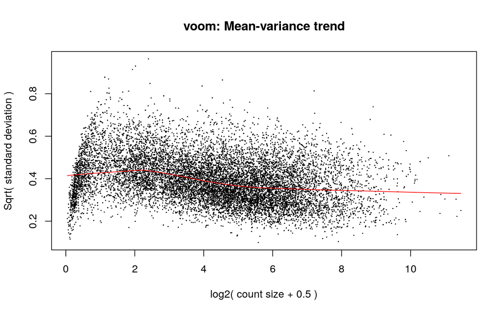

```r
# Now we simply generate new log CPM expression values, starting from the correct expression values.
mm <- model.matrix(~0+Sample, metadata)
y <- voom(corrcounts_v1, mm, plot = T)
```

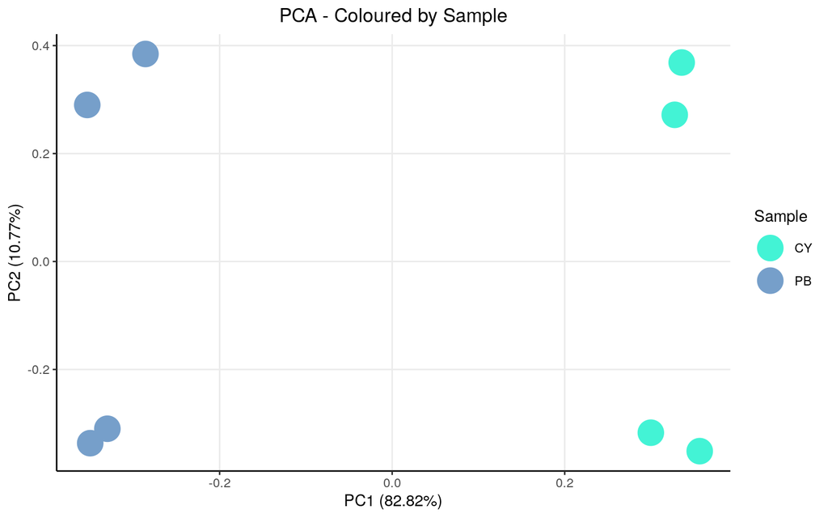

```r
#This prepares my data for the PCA
dfforpca <- y$E
dfforpca <- t(dfforpca)
dfforpca <- as.data.frame(dfforpca) # needs to be a data.frame
dfforpca <- apply(dfforpca, 2, as.numeric) # Ensure numeric
dfforpca <- as.data.frame(dfforpca) # still needs to be a data.frame

# Add metadata, which we will then use to plot
dfforpca$Sample <- sampletype
dfforpca$Cell <- celltype

# PCA computation itself. I do one PCA for each variable I want to see.
pca_res <- prcomp(dfforpca[, 1:(ncol(dfforpca)-3)], scale = FALSE)

p_Sample <- autoplot(pca_res, data = dfforpca, x = 1, y = 2, colour = "Sample", size = 8) +
  theme_bw() +
  scale_colour_manual(name = "Sample", values = custom_palette) +
  ggtitle("PCA - Coloured by Sample") +
  theme(plot.title = element_text(hjust = 0.5),
        axis.line = element_line(colour = "black"),
        panel.grid.minor = element_blank(),
        panel.border = element_blank(),
        panel.background = element_blank())

p_cell <- autoplot(pca_res, data = dfforpca, x = 1, y = 2, colour = "Cell", size = 8) +
  theme_bw() +
  scale_colour_manual(name = "Cell", values = custom_palette) +
  ggtitle("PCA - Coloured by Cell") +
  theme(plot.title = element_text(hjust = 0.5),
        axis.line = element_line(colour = "black"),
        panel.grid.minor = element_blank(),
        panel.border = element_blank(),
        panel.background = element_blank())

p_Sample
```

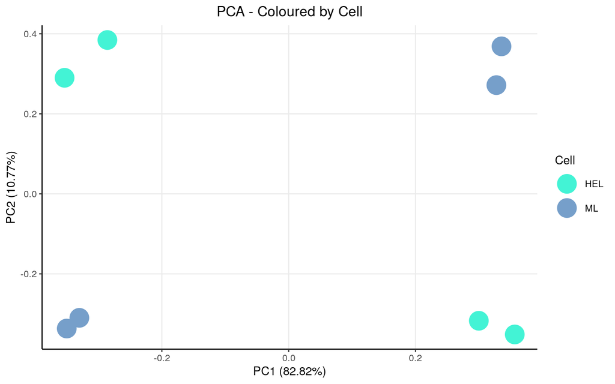

```r
p_cell
```

```r
#in case you want to see most important genes for PCA yourself
contribs1 <- pca_res$rotation[,1]
contribs2 <- pca_res$rotation[,2]

#These are the biggest contributors to the PCA1 (right side)
(pos1genes <- sort(contribs1, decreasing=T)[1:10])
```

```
##    SELENON     RNF187      RBM38    RNPEPL1      TTYH3      STK11       UPF1
## 0.02700591 0.02650675 0.02649298 0.02600866 0.02519869 0.02481040 0.02477113
##     ANKRD9      CROCC     FBRSL1
## 0.02455752 0.02403958 0.02392443
```

```r
#These are the biggest contributors to the PCA1 (left side)
(neg1genes <- sort(contribs1, decreasing=F)[1:10])
```

```
##         ZFY      ZNF766       ZNF92        FGD4       JADE1       FBXO5
## -0.02418682 -0.02383931 -0.02328551 -0.02318297 -0.02300574 -0.02285019
##        PUS3        OBI1        GAPT       IFIT2
## -0.02266112 -0.02260665 -0.02253771 -0.02241111
```

```r
#These are the biggest contributors to the PCA2 (up side)
(pos2genes <- sort(contribs2, decreasing=T)[1:10])
```

```
##      RGS17     LIMCH1        DMD      MECOM      GPR85     ZNF141    CCDC141
## 0.05685760 0.05168562 0.05021024 0.04635319 0.04533981 0.04425573 0.04026114
##      ROBO2      MAGI1    CFAP210
## 0.03761755 0.03702704 0.03663310
```

```r
#These are the biggest contributors to the PCA2 (down side)
(neg2genes <- sort(contribs2, decreasing=F)[1:10])
```

```
##       CENPE      ITGA2B         VWF       RUSF1       IGF2R         CD9
## -0.04037162 -0.03985908 -0.03950968 -0.03677350 -0.03641117 -0.03595985
##        EDC4       PIAS3         TPR       ATG9A
## -0.03536880 -0.03413501 -0.03378754 -0.03322677
```

After batch correction, as one can observe from the PCAs, our PC1 is now explained by sample type.

Now I will directly compare the PB to the Cytoplasm.

## Linear Models

```r
mm <- model.matrix(~0+Sample, metadata)
fitted <- lmFit(y$E, mm)
head(coef(fitted))
```

```
##       SampleCY SamplePB
## AAAS  6.668879 5.970956
## AACS  5.412799 4.237938
## AAGAB 5.408330 5.383528
## AAK1  4.509591 4.471227
## AAMDC 2.837493 2.462109
## AAMP  7.499037 6.872705
```

```r
#next we measure contrasts between groups (log-fold change is obtained from these fitted linear models)
contr<- makeContrasts(SamplePB  - SampleCY, levels = colnames(coef(fitted)))

#next we estimate the contrast for each gene
tmp <- contrasts.fit(fitted, contr)


#use empirical bayes smoothing of standard erros (shrinks extreme standard erros)
tmp <- eBayes(tmp)
top.table <- topTable(tmp, sort.by = "logFC", n = Inf)
DEGenes <- top.table
ndegs=20
```

## PBody vs Cytoplasm

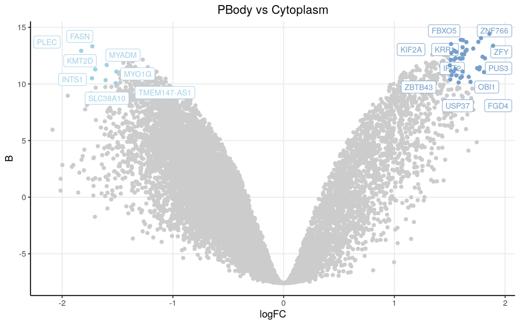

```r
upmarkers <- as.data.frame(DEGenes[DEGenes$logFC>1.5 & DEGenes$B>10,] )
downmarkers <- as.data.frame(DEGenes[DEGenes$logFC< -1.5 & DEGenes$B>10,] )

ggplot(data=DEGenes,
                 aes(x=logFC,
                     y=  B)) +
  geom_point(color="#CCCCCC")+
  theme_bw() +
  theme(axis.line = element_line(colour = "black"),
        panel.grid.minor = element_blank(),
        panel.border = element_blank(),
        panel.background = element_blank()) +
  ggtitle("PBody vs Cytoplasm")+
  theme(plot.title = element_text(hjust = 0.5)) +
  geom_label_repel(upmarkers[1:ndegs,] , mapping=aes(label=row.names(upmarkers)[1:ndegs]),size=3,point.padding=-0.5, color="#769fca",max.overlaps = 20)+
  geom_label_repel(downmarkers[1:ndegs,] , mapping=aes(label=row.names(downmarkers)[1:ndegs]),size=3,point.padding=-0.5, color="#a2d1e6",max.overlaps = 20)+
  geom_point(data=upmarkers, aes(x=logFC, y=  B), color="#769fca")+
  geom_point(data=downmarkers, aes(x=logFC, y=  B), color="#a2d1e6")
```

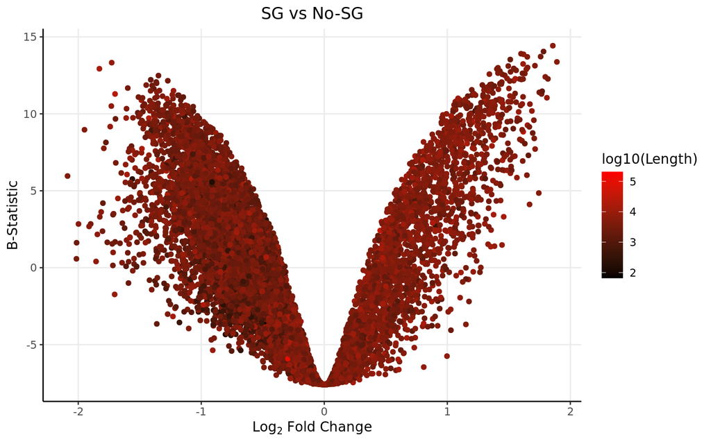

```r
DEGenes$Gene <- row.names(DEGenes)
colnames(genelength) <- c("Length","Gene")
DEGenes <- merge(DEGenes, genelength, by="Gene")

Pbody <- DEGenes[,c(1,2,4,8)]

ggplot(data=DEGenes,
                 aes(x=logFC,
                     y=  B)) +
  geom_point(aes(color=log10(Length)))+
  theme_bw() +
  theme(axis.line = element_line(colour = "black"),
        panel.grid.minor = element_blank(),
        panel.border = element_blank(),
        panel.background = element_blank()) +
  ggtitle("SG vs No-SG")+ xlab(expression(Log[2] ~ Fold ~ Change)) + ylab("B-Statistic") +
  theme(plot.title = element_text(hjust = 0.5))  +
  scale_colour_gradient(low = "black", high = "red")+ theme(text=element_text(family = "Quicksand"))
```

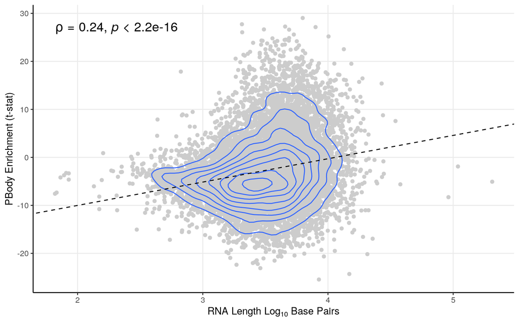

```r
smooth.SG <- lm(t~log10(Length), DEGenes)


ggplot(DEGenes, aes(y=t, x=log10(Length))) + geom_point(color="#CCCCCC", alpha=1) +   theme_bw()+ geom_density_2d()+
 ylab("PBody Enrichment (t-stat)") + xlab(expression(RNA ~ Length ~ Log[10] ~ Base ~ Pairs)) +
  theme(axis.line = element_line(colour = "black"),
        panel.grid.minor = element_blank(),
        panel.border = element_blank(),
        panel.background = element_blank()) +
  theme(plot.title = element_text(hjust = 0.5))  +
  geom_abline(slope=smooth.SG$coefficients[2], intercept = smooth.SG$coefficients[1], linetype = "dashed") + stat_cor(method = "spearman", cor.coef.name = "rho", size=5)
```

```r
newpbody_t <- DEGenes

write.table(newpbody_t, "~/Projects/StressGranules/SGPAPER/BrunoPbo.txt", row.names = F)
```

Now, even though we still obtain a positive length bias, even just by looking at the plot, we can tell it is not as strong as stressed SGs isolated through DC.

# Alltogether Now

Finally, I will compare the two isolation methods directly.

```r
raw.read.counts <- read.table("~/Projects/StressGranules/SG_Transcriptome/P_Bodies/alignment_STAR/featureCounts_results.txt", header = T)[,-c(2:6)]

biomart <- fread("~/biomart.txt")[,-1]

colnames(raw.read.counts)[1] <- "ensembl_gene_id_version"
colnames(biomart) <- c("ensembl_gene_id_version", "hgnc_symbol")

eltable <- merge(raw.read.counts,biomart,by = "ensembl_gene_id_version", all= TRUE) #this creates a table with both ensemble ids and HGNC codes.

eltable <- subset(eltable, hgnc_symbol!="")
eltable$ensembl_gene_id_version <- NULL#this removes reads that dont have a corresponding hgnc symbol.
read.counts <- eltable %>%
  group_by(hgnc_symbol) %>%
  summarise(across(everything(), sum, na.rm = TRUE))

read.counts <- as.data.frame(read.counts)

stress.read.counts <- read.counts

colnames(stress.read.counts) <- c("Gene", "PBWT1", "PBWT2", "PBWT3", "PBKO1", "PBKO2", "PBKO3", "WCWT1", "WCWT2", "WCWT3", "KOWT1", "KOWT2", "KOWT3")

newpbody1 <- fread("~/Projects/StressGranules/SG_Transcriptome/P_Bodies/GSE224752_HEL_Counts.txt")
colnames(newpbody1) <- c("Gene","HPB1", "HPB2", "HCY1", "HCY2")
newpbody2 <- fread("~/Projects/StressGranules/SG_Transcriptome/P_Bodies/GSE224752_MOLM13_Counts.txt.gz")
colnames(newpbody2) <- c("Gene","MCY1", "MCY2", "MPB1", "MPB2")


read.counts1 <- newpbody1 %>%
  group_by(Gene) %>%
  summarise(across(everything(), sum, na.rm = TRUE))

read.counts2 <- newpbody2 %>%
  group_by(Gene) %>%
  summarise(across(everything(), sum, na.rm = TRUE))

newpbody <- merge(read.counts1, read.counts2, by="Gene")

stress.read.counts <- merge(stress.read.counts, newpbody, by="Gene")

stress.read.counts <- stress.read.counts %>%
  group_by(Gene) %>%
  summarise(across(everything(), sum, na.rm = TRUE))


stress.read.counts <- as.data.frame(stress.read.counts)
row.names(stress.read.counts) <- stress.read.counts$Gene
stress.read.counts$Gene <- NULL
```

## Extra Quality Control

Let’s check for sample complexity. It is possible that one or more samples have different complexity. In specific, I am going to check if enough reads have been obtained from every sample. If not, we should have a great bias to housekeeping genes. Another way to put it, is to say that even with all reads, we won’t obtain a great deal of different genes.

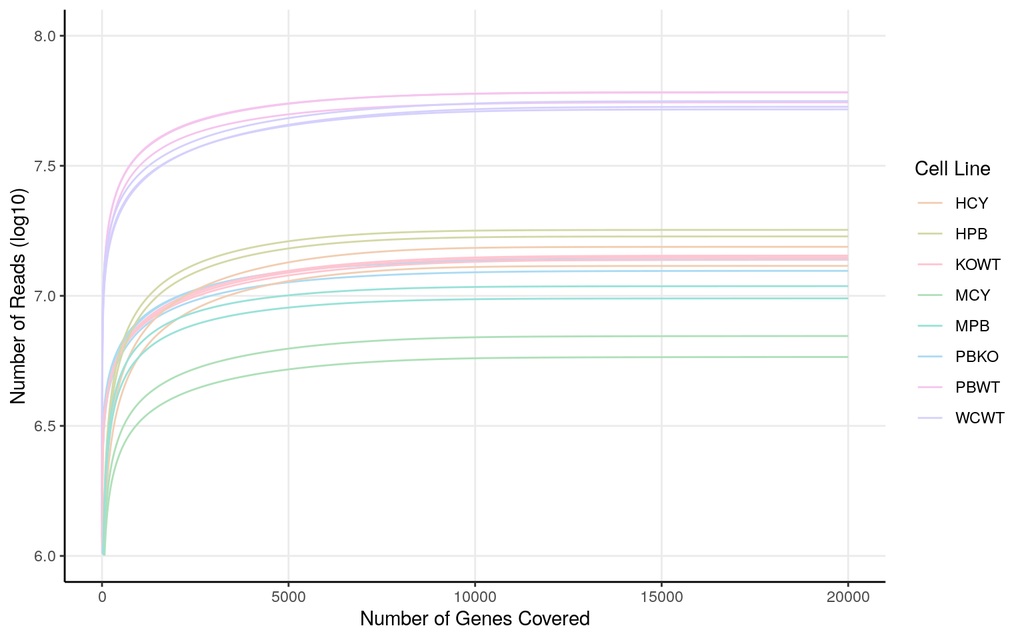

```r
#In here, I am just defining some colours to use
custom_palette <- qualitative_hcl(8, palette = "Pastel")
custom_palette <- sample(custom_palette, 8)

# Variable that I wish to colour
SampleColouring <- c("PBWT", "PBWT", "PBWT", "PBKO", "PBKO", "PBKO", "WCWT", "WCWT", "WCWT", "KOWT", "KOWT", "KOWT","HPB", "HPB", "HCY", "HCY","MCY", "MCY", "MPB", "MPB")

# Build cumulative counts
final <- sapply(1:ncol(stress.read.counts), function(i) {
  sort_vals <- stress.read.counts[order(stress.read.counts[, i], decreasing = TRUE), i]
  cumsum(sort_vals)
})
final <- as.data.frame(final)
colnames(final) <- colnames(stress.read.counts)

# Melt and add gene position + sample info
finalmelt <- reshape2::melt(final, variable.name = "Sample")
finalmelt$genes <- rep(1:nrow(final), times = ncol(final))
finalmelt$SampleColouring <- rep(SampleColouring, each = nrow(final))

# Plot cumulative read coverage
ggplot(data = finalmelt, aes(x = genes, y = log10(value), group = Sample, color = SampleColouring)) +
  geom_line() +
  scale_color_manual(values = custom_palette, name = "Cell Line") +
  theme_bw() +
  xlab("Number of Genes Covered") +
  ylab("Number of Reads (log10)") +
  xlim(0, 20000) +
  ylim(6, 8) +
  theme(
    axis.line = element_line(colour = "black"),
    panel.grid.minor = element_blank(),
    panel.border = element_blank(),
    panel.background = element_blank()
  )
```

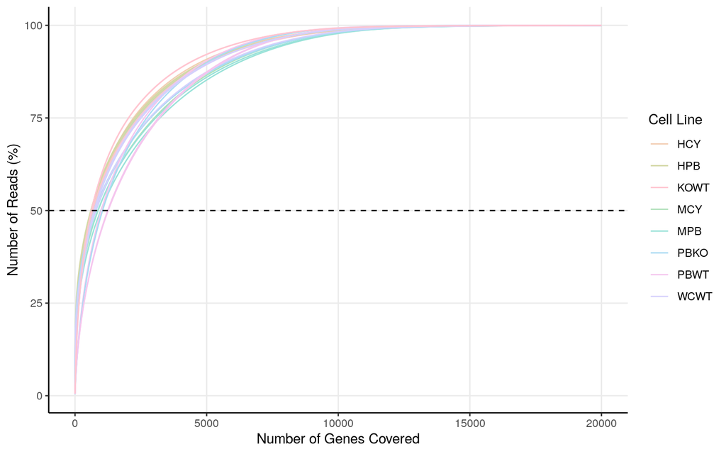

```r
# Create percentage-based plot
orderfinal <- subset(finalmelt, genes == max(finalmelt$genes))
trial <- merge(orderfinal[, c("Sample", "value")], finalmelt, by = "Sample", suffixes = c(".total", ".current"))
trial$percent <- (trial$value.current / trial$value.total) * 100
trial$SampleColouring <- rep(SampleColouring, each = nrow(final))

ggplot(data = trial, aes(x = genes, y = percent, group = Sample, color = SampleColouring)) +
  geom_line() +
  geom_hline(yintercept = 50, linetype = "dashed") +
  scale_color_manual(values = custom_palette, name = "Cell Line") +
  xlab("Number of Genes Covered") +
  ylab("Number of Reads (%)") +
  xlim(0, 20000) +
  theme_bw() +
  theme(
    axis.line = element_line(colour = "black"),
    panel.grid.minor = element_blank(),
    panel.border = element_blank(),
    panel.background = element_blank()
  )
```

# Differential Expression Analysis

## Filtration

### *Before Filtration*

Let us begin with the filtration.

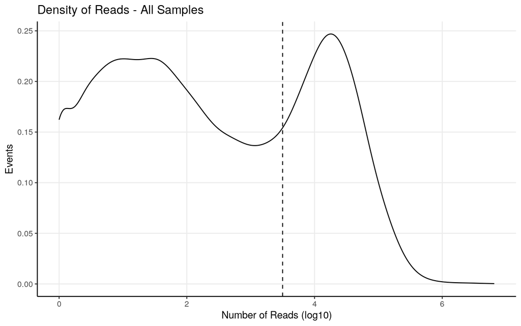

```r
alternew <- log10(rowSums(stress.read.counts))
alternew <- as.data.frame(alternew)

ggplot(alternew, aes(x=alternew)) + geom_density() + theme_bw() + geom_vline(xintercept = 3.5, linetype = "dashed") + ylab("Events") + xlab("Number of Reads (log10)") +
  theme(axis.line = element_line(colour = "black"),
        panel.grid.minor = element_blank(),
        panel.border = element_blank(),
        panel.background = element_blank()) + ggtitle("Density of Reads - All Samples")
```

By seeing the shape of the graph, we can see where we should cut. We have a **binomial distribution** (low reads and noise vs actual biological meaningful reads). The ideal place to cut them is right before the wedge.

### *After Filtration*

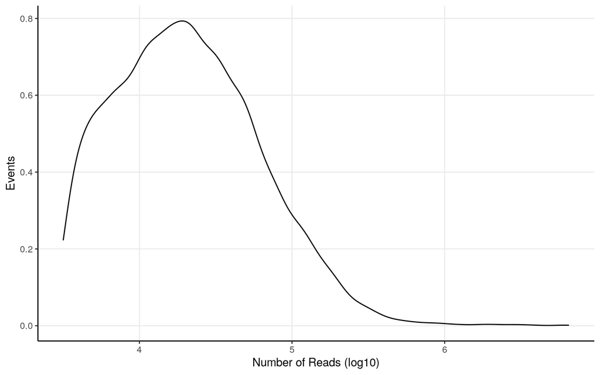

```r
filterednew <- subset(stress.read.counts, alternew>3.5)


#after cutting, its a good idea to visualize again
falternew <- log10(rowSums(filterednew))
falternew <- as.data.frame(falternew)
ggplot(falternew, aes(x=falternew)) + geom_density() + theme_bw() + ylab("Events") + xlab("Number of Reads (log10)") +
  theme(axis.line = element_line(colour = "black"),
        panel.grid.minor = element_blank(),
        panel.border = element_blank(),
        panel.background = element_blank())
```

```r
#lets save the genes which we maintain
impgenes <- c(row.names(falternew))

#Now we need to select only the rows which have those genes.
finaltable <- stress.read.counts[row.names(stress.read.counts)%in%impgenes,]
```

## Matrices

Good! Now we can proceed by designing our matrices.

```
## Coefficients not estimable: Study2 StressYES
```

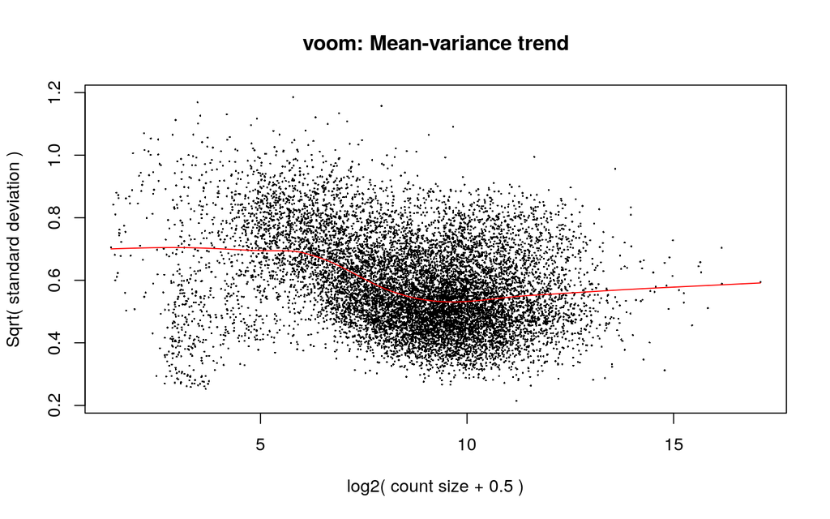

```r
#Let us prepare metadata to add to our samples

forcell <- c(rep("U2OS",12), rep("Hela",4), rep("MOLM",4))
forg3 <- c(rep("WT",3),rep("KO",3),rep("WT",3),rep("KO",3),rep("WT",8))
formethod <- c(rep("DC",6),rep("WC",6),rep("FAPS",2),rep("WC",2),rep("FAPS",2),rep("WC",2))
forstudy <- c(rep("1",12), rep("2",8))
forstress <- c(rep("YES",12), rep("NO",8))

metadata <- data.frame(Cell=forcell, G3=forg3, Method=formethod, Study=forstudy, Stress=forstress)

#To be able to use Voom, we must first convert our read count table into a special DGE object.
D0 <- DGEList(finaltable)

#for the others, we need to select only relevant columns.

#Then we calculate the normalization factors.
#Bear in mind this step calculates the normalization factors, but does not normalize itself.
D0 <- calcNormFactors(D0)


#Now we do our matrix itself
mm <- model.matrix(~0+Cell+G3+Method+Study+Stress, metadata)

#and now we normalize. This step also turns our counts into log2-counts per million.
y <- voom(D0, mm, plot = T)
```

## Normalisation

For normalisation I convert the read counts into log2CPMs. Its a good way to visualise how the reads are.

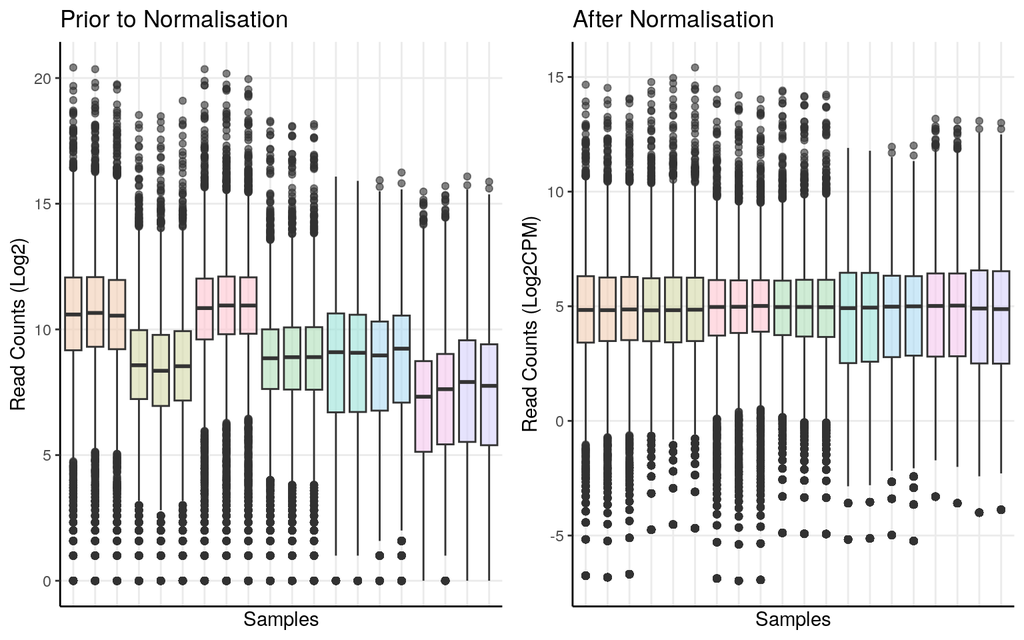

```r
dfforboxy <- finaltable

orderforplots <- SampleColouring
colouring <- data.frame(Sample=colnames(dfforboxy), Types=orderforplots)
dfforboxy <- reshape2::melt(dfforboxy)
colnames(dfforboxy) <- c("Sample", "Expression")
dfforboxy <- merge(dfforboxy, colouring, by="Sample")
prenorm <- ggplot(dfforboxy, aes(x=Sample, y=(log2(Expression+1)), fill=Types)) + geom_boxplot(alpha=0.6) + theme_bw() + ylab("Read Counts (Log2)") + xlab("Samples") + scale_fill_manual(name = "Sample Type", values = custom_palette, labels=unique(SampleColouring), breaks =unique(SampleColouring)) +
  theme(axis.line = element_line(colour = "black"),
        panel.grid.minor = element_blank(),
        panel.border = element_blank(),
        panel.background = element_blank(),
        axis.text.x=element_blank(),
        axis.ticks.x=element_blank(),
        legend.position = "None") + ggtitle("Prior to Normalisation")

dfforboxy <- y$E
dfforboxy <- reshape2::melt(dfforboxy)
dfforboxy <- dfforboxy[,-1]
colnames(dfforboxy) <- c("Sample", "Expression")
dfforboxy <- merge(dfforboxy, colouring, by="Sample")
postnorm <- ggplot(dfforboxy, aes(x=Sample, y=Expression, fill=Types)) + geom_boxplot(alpha=0.6) + theme_bw() + ylab("Read Counts (Log2CPM)") + xlab("Samples") + scale_fill_manual(name = "Sample Type", values = custom_palette, labels=unique(SampleColouring), breaks =unique(SampleColouring)) +
  theme(axis.line = element_line(colour = "black"),
        panel.grid.minor = element_blank(),
        panel.border = element_blank(),
        panel.background = element_blank(),
        axis.text.x=element_blank(),
        axis.ticks.x=element_blank(),
        legend.position = "None") + ggtitle("After Normalisation")

ggarrange(prenorm, postnorm, nrow=1)
```

## PCA

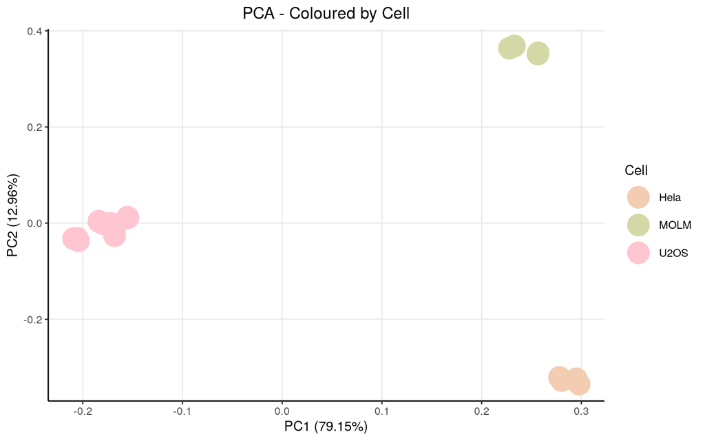

```r
#Here I am just setting up the colours to use
prettycolours <- custom_palette

#This prepares my data for the PCA
dfforpca <- y$E
dfforpca <- t(dfforpca)
dfforpca <- as.data.frame(dfforpca) # needs to be a data.frame
dfforpca <- apply(dfforpca, 2, as.numeric) # Ensure numeric
dfforpca <- as.data.frame(dfforpca) # still needs to be a data.frame

# Add metadata, which we will then use to plot
dfforpca$Cell <- forcell
dfforpca$G3 <- forg3
dfforpca$Method <- formethod
dfforpca$Study <- forstudy
dfforpca$Stress <- forstress

# PCA computation itself. I do one PCA for each variable I want to see.
pca_res <- prcomp(dfforpca[, 1:(ncol(dfforpca)-5)], scale = FALSE)

p_cell <- autoplot(pca_res, data = dfforpca, x = 1, y = 2, colour = "Cell", size = 8) +
  theme_bw() +
  scale_colour_manual(name = "Cell", values = custom_palette) +
  ggtitle("PCA - Coloured by Cell") +
  theme(plot.title = element_text(hjust = 0.5),
        axis.line = element_line(colour = "black"),
        panel.grid.minor = element_blank(),
        panel.border = element_blank(),
        panel.background = element_blank())

p_g3 <- autoplot(pca_res, data = dfforpca, x = 1, y = 2, colour = "G3", size = 8) +
  theme_bw() +
  scale_colour_manual(name = "G3", values = custom_palette) +
  ggtitle("PCA - Coloured by G3") +
  theme(plot.title = element_text(hjust = 0.5),
        axis.line = element_line(colour = "black"),
        panel.grid.minor = element_blank(),
        panel.border = element_blank(),
        panel.background = element_blank())

p_method <- autoplot(pca_res, data = dfforpca, x = 1, y = 2, colour = "Method", size = 8) +
  theme_bw() +
  scale_colour_manual(name = "Method", values = custom_palette) +
  ggtitle("PCA - Coloured by Method") +
  theme(plot.title = element_text(hjust = 0.5),
        axis.line = element_line(colour = "black"),
        panel.grid.minor = element_blank(),
        panel.border = element_blank(),
        panel.background = element_blank())

p_Study <- autoplot(pca_res, data = dfforpca, x = 1, y = 2, colour = "Study", size = 8) +
  theme_bw() +
  scale_colour_manual(name = "Study", values = custom_palette) +
  ggtitle("PCA - Coloured by Study") +
  theme(plot.title = element_text(hjust = 0.5),
        axis.line = element_line(colour = "black"),
        panel.grid.minor = element_blank(),
        panel.border = element_blank(),
        panel.background = element_blank())

p_Stress <- autoplot(pca_res, data = dfforpca, x = 1, y = 2, colour = "Stress", size = 8) +
  theme_bw() +
  scale_colour_manual(name = "Stress", values = custom_palette) +
  ggtitle("PCA - Coloured by Stress") +
  theme(plot.title = element_text(hjust = 0.5),
        axis.line = element_line(colour = "black"),
        panel.grid.minor = element_blank(),
        panel.border = element_blank(),
        panel.background = element_blank())

p_cell
```

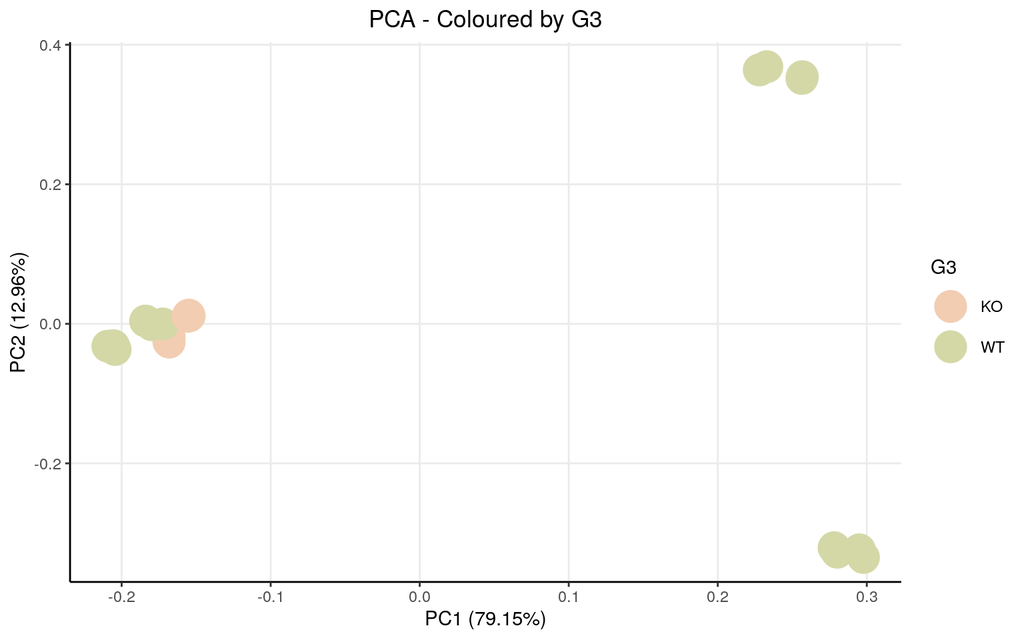

```r
p_g3
```

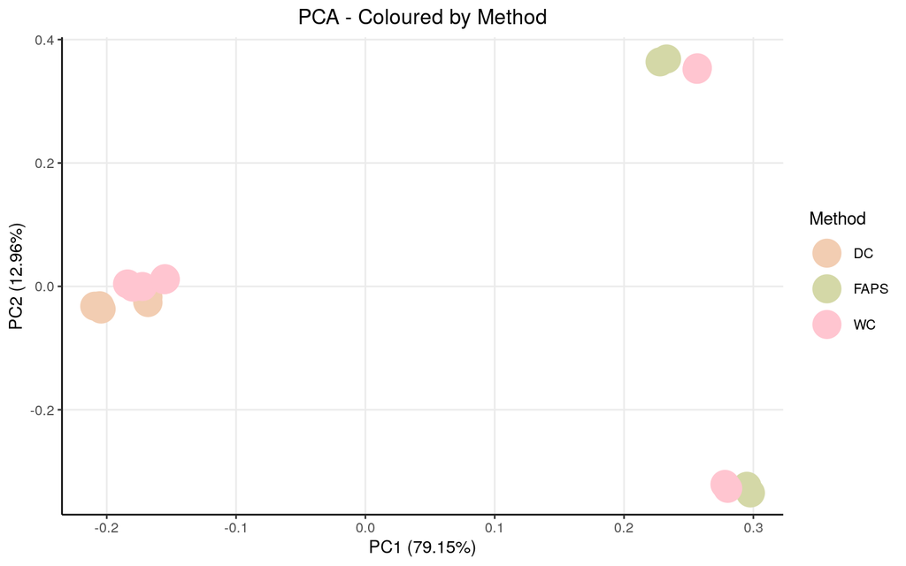

```r
p_method
```

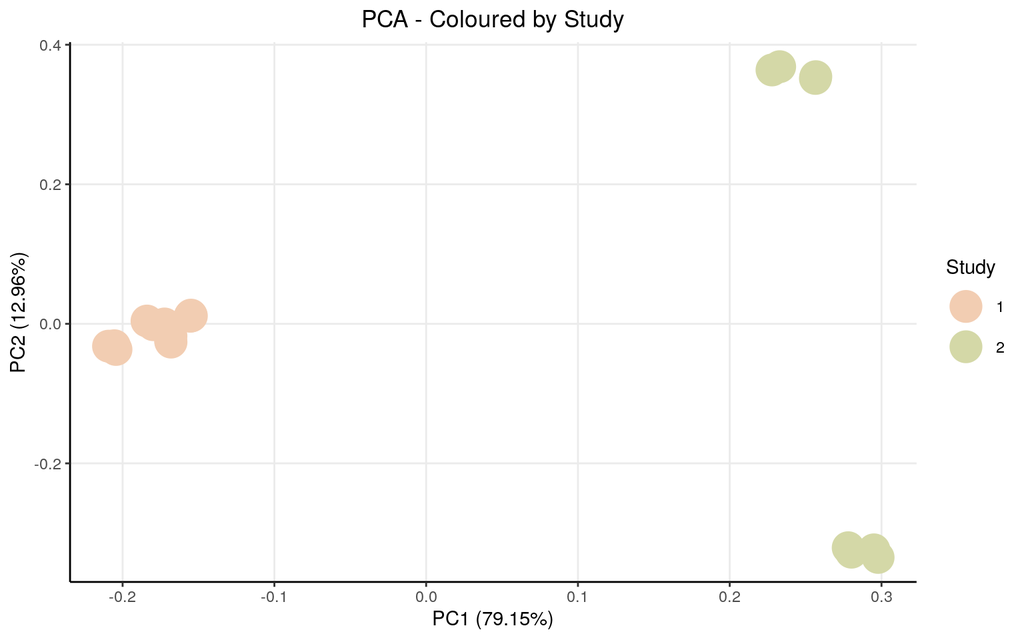

```r
p_Study
```

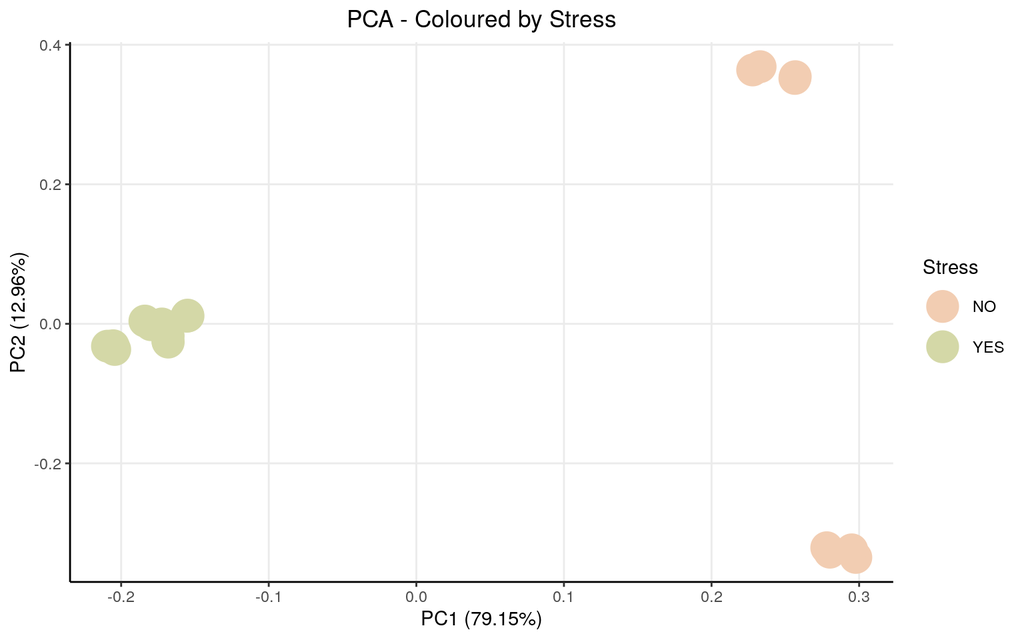

```r
p_Stress
```

```r
#in case you want to see most important genes for PCA yourself
contribs1 <- pca_res$rotation[,1]
contribs2 <- pca_res$rotation[,2]

#These are the biggest contributors to the PCA1 (right side)
(pos1genes <- sort(contribs1, decreasing=T)[1:10])
```

```
##      EIF3A     MALAT1      EIF5B       LDHA      CENPF      HMGN2      LARS1
## 0.03884290 0.03850048 0.03829755 0.03708458 0.03707816 0.03612042 0.03602000
##     CEP350      MEF2C     HNRNPM
## 0.03588876 0.03572325 0.03553193
```

```r
#These are the biggest contributors to the PCA1 (left side)
(neg1genes <- sort(contribs1, decreasing=F)[1:10])
```

```
##       RN7SK        CCN2        RMRP      RN7SL2       RPPH1         7SK
## -0.03536642 -0.03377481 -0.03227065 -0.03201918 -0.03064555 -0.03044324
##       EEF1G      ANKRD1        FAT1      MAGEA4
## -0.03024633 -0.03021290 -0.03002788 -0.02906378
```

```r
#These are the biggest contributors to the PCA2 (up side)
(pos2genes <- sort(contribs2, decreasing=T)[1:10])
```

```
##      ELANE      PRTN3       AZU1        MPO       CCL5     RNASE2       ASS1
## 0.05961607 0.05939236 0.05880186 0.05824344 0.05193513 0.05045133 0.04922523
##      LAMP5       CSTA      DOCK8
## 0.04922384 0.04792966 0.04784479
```

```r
#These are the biggest contributors to the PCA2 (down side)
(neg2genes <- sort(contribs2, decreasing=F)[1:10])
```

```
##      GPR158      CAVIN2       GATA1       NPY1R       EPB42       PRAME
## -0.04334419 -0.04069863 -0.03938760 -0.03925671 -0.03903142 -0.03881015
##      LIN28B      FCER1A      ITGA2B       SCRN1
## -0.03855142 -0.03830016 -0.03824732 -0.03810724
```

# Batch Effect Correction

```r
batch_cols <- c("Cell", "Stress", "G3", "Study")
metadata_cols <- c("Method")
mmbatch <- model.matrix(reformulate(paste0("~0 + ",paste0( batch_cols,collapse = " + "))), data=metadata)
mmkeep <- model.matrix(reformulate(paste0("~0 + ",paste0( metadata_cols,collapse =  "+" ))), data=metadata)
mm <- cbind(mmkeep,mmbatch)
D0 <- DGEList(2^y$E) #senescence_normcounts
D0 <- calcNormFactors(D0)
y <- voom(D0, mm, plot = F)
```

```
## Coefficients not estimable: CellU2OS StressYES Study2
```

```r
fit <- lmFit(y, mm)
```

```
## Coefficients not estimable: CellU2OS StressYES Study2
```

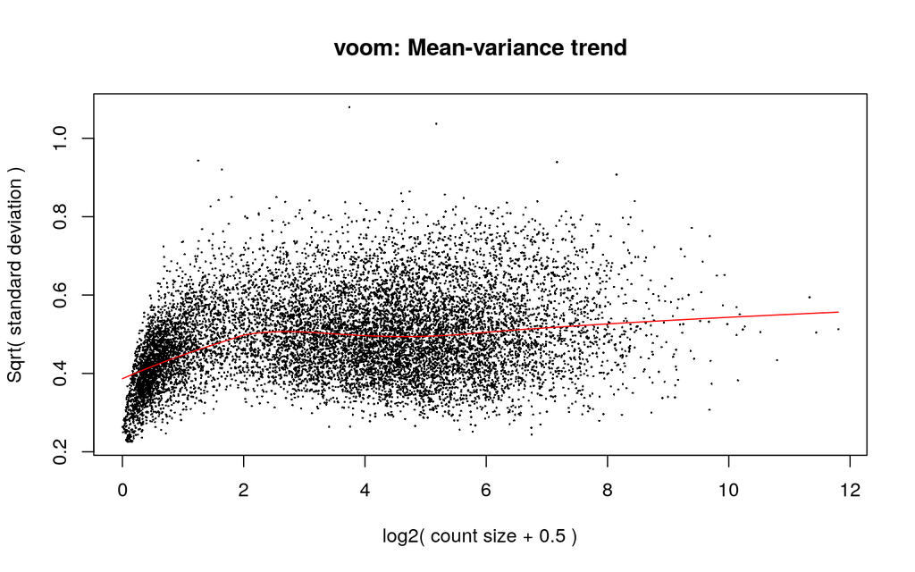

```r
beta <- fit$coefficients[,-(1:ncol(mmkeep)),drop=FALSE]
#beta <- fit$coefficients
beta[is.na(beta)] <- 0
corrcounts_v1 <- as.matrix(y$E) - beta %*% t(mmbatch)
offset <- apply(corrcounts_v1,1,min) - apply(y$E,1,min)
corrcounts_v1 <- as.data.frame(corrcounts_v1-offset)
corrcounts_v1 <- 2^corrcounts_v1

mm <- model.matrix(~0+Method, metadata)

y <- voom(corrcounts_v1, mm, plot = T)
```

## Batch Corrected PCA

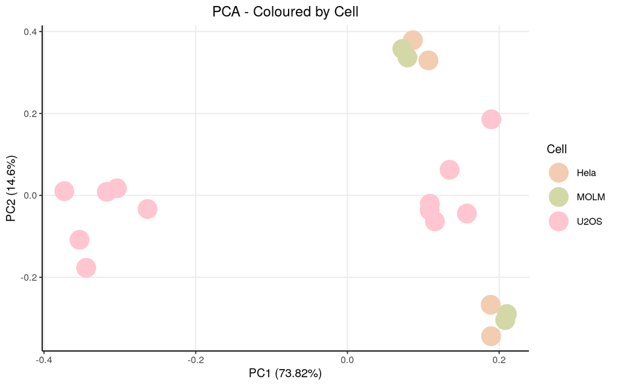

```r
#This prepares my data for the PCA
dfforpca <- y$E
dfforpca <- t(dfforpca)
dfforpca <- as.data.frame(dfforpca) # needs to be a data.frame
dfforpca <- apply(dfforpca, 2, as.numeric) # Ensure numeric
dfforpca <- as.data.frame(dfforpca) # still needs to be a data.frame

# Add metadata, which we will then use to plot
dfforpca$Cell <- forcell
dfforpca$G3 <- forg3
dfforpca$Method <- formethod
dfforpca$Study <- forstudy
dfforpca$Stress <- forstress

# PCA computation itself. I do one PCA for each variable I want to see.
pca_res <- prcomp(dfforpca[, 1:(ncol(dfforpca)-5)], scale = FALSE)

p_cell <- autoplot(pca_res, data = dfforpca, x = 1, y = 2, colour = "Cell", size = 8) +
  theme_bw() +
  scale_colour_manual(name = "Cell", values = custom_palette) +
  ggtitle("PCA - Coloured by Cell") +
  theme(plot.title = element_text(hjust = 0.5),
        axis.line = element_line(colour = "black"),
        panel.grid.minor = element_blank(),
        panel.border = element_blank(),
        panel.background = element_blank())

p_g3 <- autoplot(pca_res, data = dfforpca, x = 1, y = 2, colour = "G3", size = 8) +
  theme_bw() +
  scale_colour_manual(name = "G3", values = custom_palette) +
  ggtitle("PCA - Coloured by G3") +
  theme(plot.title = element_text(hjust = 0.5),
        axis.line = element_line(colour = "black"),
        panel.grid.minor = element_blank(),
        panel.border = element_blank(),
        panel.background = element_blank())

p_method <- autoplot(pca_res, data = dfforpca, x = 1, y = 2, colour = "Method", size = 8) +
  theme_bw() +
  scale_colour_manual(name = "Method", values = custom_palette) +
  ggtitle("PCA - Coloured by Method") +
  theme(plot.title = element_text(hjust = 0.5),
        axis.line = element_line(colour = "black"),
        panel.grid.minor = element_blank(),
        panel.border = element_blank(),
        panel.background = element_blank())

p_Study <- autoplot(pca_res, data = dfforpca, x = 1, y = 2, colour = "Study", size = 8) +
  theme_bw() +
  scale_colour_manual(name = "Study", values = custom_palette) +
  ggtitle("PCA - Coloured by Study") +
  theme(plot.title = element_text(hjust = 0.5),
        axis.line = element_line(colour = "black"),
        panel.grid.minor = element_blank(),
        panel.border = element_blank(),
        panel.background = element_blank())

p_Stress <- autoplot(pca_res, data = dfforpca, x = 1, y = 2, colour = "Stress", size = 8) +
  theme_bw() +
  scale_colour_manual(name = "Stress", values = custom_palette) +
  ggtitle("PCA - Coloured by Stress") +
  theme(plot.title = element_text(hjust = 0.5),
        axis.line = element_line(colour = "black"),
        panel.grid.minor = element_blank(),
        panel.border = element_blank(),
        panel.background = element_blank())

p_cell
```

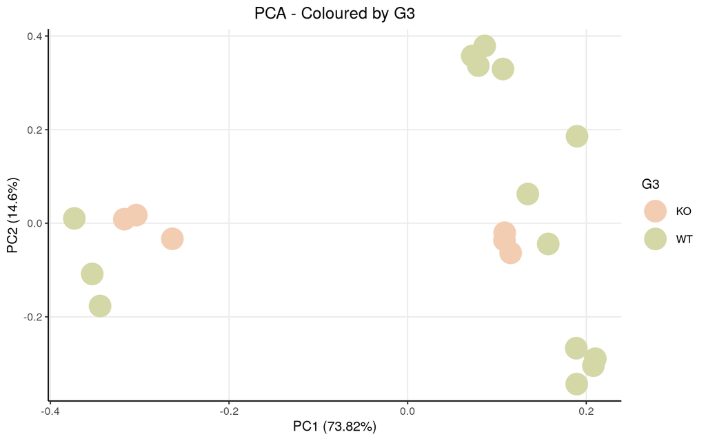

```r
p_g3
```

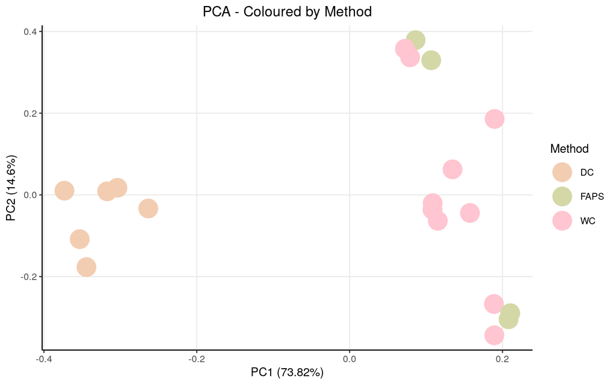

```r
p_method
```

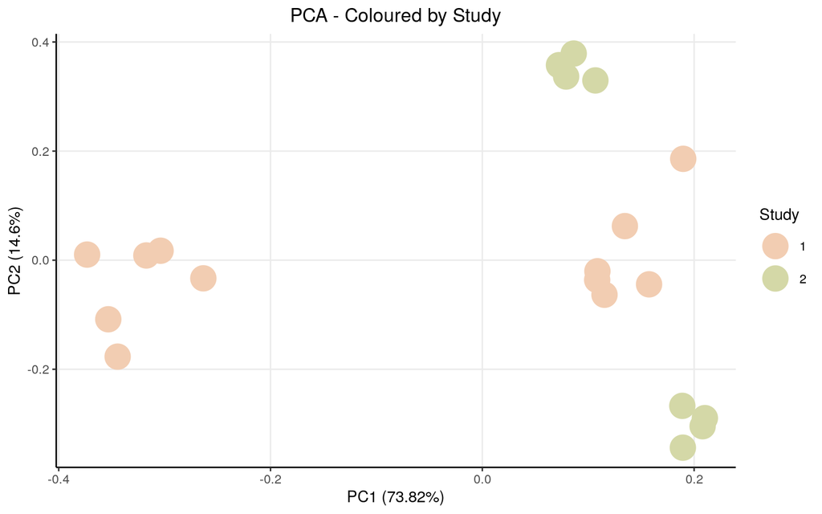

```r
p_Study
```

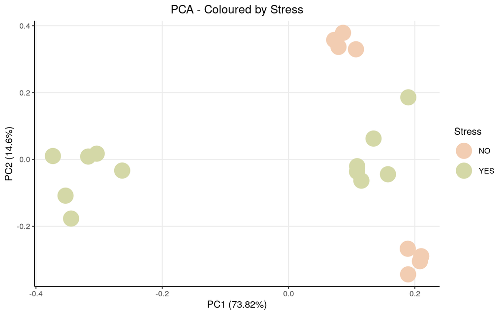

```r
p_Stress
```

```r
#in case you want to see most important genes for PCA yourself
contribs1 <- pca_res$rotation[,1]
contribs2 <- pca_res$rotation[,2]

#These are the biggest contributors to the PCA1 (right side)
(pos1genes <- sort(contribs1, decreasing=T)[1:10])
```

```
##     RN7SL1     RN7SL2     RN7SL3      RPPH1    RN7SL4P        7SK      RN7SK
## 0.07994775 0.06869701 0.06678645 0.06259723 0.05982461 0.04939900 0.04859834
##       H3C2       H4C9      RPS29
## 0.04056754 0.03654328 0.03619797
```

```r
#These are the biggest contributors to the PCA1 (left side)
(neg1genes <- sort(contribs1, decreasing=F)[1:10])
```

```
##       MT-TG      MT-TL2       MT-TR       MT-TH      MT-TS2      ZNF107
## -0.03776545 -0.03756655 -0.03721299 -0.03570455 -0.03555547 -0.02782616
##        SACS      BOD1L1       AHNAK      ZNF678
## -0.02566797 -0.02490036 -0.02458649 -0.02435325
```

```r
#These are the biggest contributors to the PCA2 (up side)
(pos2genes <- sort(contribs2, decreasing=T)[1:10])
```

```
##      USP16      CENPQ       KRR1       PUS3     UBLCP1      NOC3L      CWC27
## 0.02945756 0.02934835 0.02879175 0.02851297 0.02824074 0.02786961 0.02782537
##      LARP7      USPL1     ERGIC2
## 0.02776534 0.02761791 0.02745054
```

```r
#These are the biggest contributors to the PCA2 (down side)
(neg2genes <- sort(contribs2, decreasing=F)[1:10])
```

```
##        PLEC       KMT2D       CROCC      FBRSL1       TTYH3      NOTCH1
## -0.03307011 -0.03221372 -0.03145738 -0.02970339 -0.02951967 -0.02927334
##    TNKS1BP1      SEC16A        UPF1     RNPEPL1
## -0.02923971 -0.02898223 -0.02873396 -0.02853401
```

# DC PB vs WC

## Linear Models

Now we must perform linear model fitting. Once more, we will have 4, one for each matrix we previously designed.

```r
mm <- model.matrix(~0+formethod)
fitted <- lmFit(y$E, mm)
head(coef(fitted))
```

```
##          formethodDC formethodFAPS formethodWC
## 7SK         1.465756      6.556158    6.505453
## A1BG-AS1    2.399231      1.980571    1.859790
## AAAS        5.036134      6.198288    6.361196
## AACS        5.534681      5.438987    5.768844
## AADAT       1.194210      1.637157    1.607967
## AAGAB       5.821023      6.145345    6.506165
```

```r
#
contrat <- makeContrasts(formethodDC  - formethodWC, levels =colnames(coef(fitted)))
#
contrat <- contrasts.fit(fitted, contrat)
#
# #Correction for multiple testing
contrat <- eBayes(contrat)
#
top.table <- topTable(contrat,  sort.by = "logFC", n=Inf)
DEGenes <- top.table
```

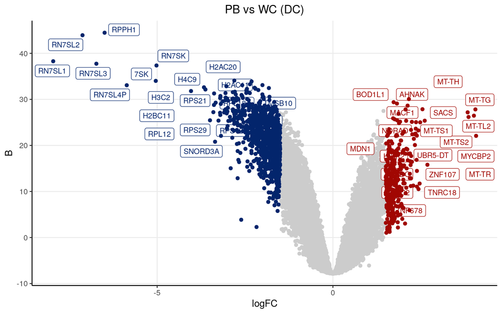

```r
upmarkers <- as.data.frame(DEGenes[DEGenes$logFC>1.5 & DEGenes$B>0,] )
downmarkers <- as.data.frame(DEGenes[DEGenes$logFC< -1.5 & DEGenes$B>0,] )

ggplot(data=DEGenes,
                 aes(x=logFC,
                     y=  B)) +
  geom_point(color="#CCCCCC")+
  theme_bw() +
  theme(axis.line = element_line(colour = "black"),
        panel.grid.minor = element_blank(),
        panel.border = element_blank(),
        panel.background = element_blank()) +
  ggtitle("PB vs WC (DC)")+
  theme(plot.title = element_text(hjust = 0.5)) +
  geom_label_repel(upmarkers[1:ndegs,] , mapping=aes(label=row.names(upmarkers)[1:ndegs]),size=3,point.padding=-0.5, color="#A10702",max.overlaps = 20)+
  geom_label_repel(downmarkers[1:ndegs,] , mapping=aes(label=row.names(downmarkers)[1:ndegs]),size=3,point.padding=-0.5, color="#03256C",max.overlaps = 20)+
  geom_point(data=upmarkers, aes(x=logFC, y=  B), color="#A10702")+
  geom_point(data=downmarkers, aes(x=logFC, y=  B), color="#03256C")
```

```r
dc_t <- data.frame(Gene=row.names(DEGenes), dc_t=DEGenes$t)
```

# FAPS PB vs WC

## Linear Models

Now we must perform linear model fitting. Once more, we will have 4, one for each matrix we previously designed.

```r
mm <- model.matrix(~0+formethod)
fitted <- lmFit(y$E, mm)
head(coef(fitted))
```

```
##          formethodDC formethodFAPS formethodWC
## 7SK         1.465756      6.556158    6.505453
## A1BG-AS1    2.399231      1.980571    1.859790
## AAAS        5.036134      6.198288    6.361196
## AACS        5.534681      5.438987    5.768844
## AADAT       1.194210      1.637157    1.607967
## AAGAB       5.821023      6.145345    6.506165
```

```r
#
contrat <- makeContrasts(formethodFAPS   - formethodWC, levels =colnames(coef(fitted)))
#
contrat <- contrasts.fit(fitted, contrat)
#
# #Correction for multiple testing
contrat <- eBayes(contrat)
#
top.table <- topTable(contrat,  sort.by = "logFC", n=Inf)
DEGenes <- top.table
```

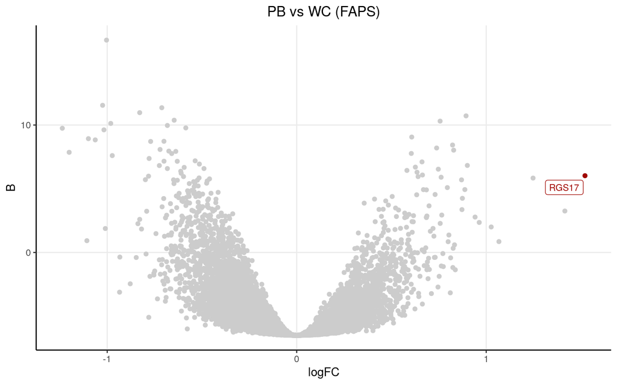

```r
upmarkers <- as.data.frame(DEGenes[DEGenes$logFC>1.5 & DEGenes$B>0,] )
downmarkers <- as.data.frame(DEGenes[DEGenes$logFC< -1.5 & DEGenes$B>0,] )

ggplot(data=DEGenes,
                 aes(x=logFC,
                     y=  B)) +
  geom_point(color="#CCCCCC")+
  theme_bw() +
  theme(axis.line = element_line(colour = "black"),
        panel.grid.minor = element_blank(),
        panel.border = element_blank(),
        panel.background = element_blank()) +
  ggtitle("PB vs WC (FAPS)")+
  theme(plot.title = element_text(hjust = 0.5)) +
  geom_label_repel(upmarkers[1:ndegs,] , mapping=aes(label=row.names(upmarkers)[1:ndegs]),size=3,point.padding=-0.5, color="#A10702",max.overlaps = 20)+
  geom_label_repel(downmarkers[1:ndegs,] , mapping=aes(label=row.names(downmarkers)[1:ndegs]),size=3,point.padding=-0.5, color="#03256C",max.overlaps = 20)+
  geom_point(data=upmarkers, aes(x=logFC, y=  B), color="#A10702")+
  geom_point(data=downmarkers, aes(x=logFC, y=  B), color="#03256C")
```

```r
faps_t <- data.frame(Gene=row.names(DEGenes), faps_t=DEGenes$t)
```